# Han-BanningGamblingLivestreams-2024-SSRN.pdf

Converted from PDF `Han-BanningGamblingLivestreams-2024-SSRN.pdf` · 63 pages · anchors: page `#pN`, block `#pN-bK`

Page 1

### The Impact of Banning Online Gambling Livestreams:

### Evidence from Twitch.tv<sup>∗</sup>

Qifan Han† Jasmine Yang‡ Andrey Simonov<sup>§</sup>

October 1, 2024

CLICK HERE FOR LATEST VERSION

#### **Abstract**

The necessity of content regulation on digital platforms, particularly concerning misinformation and harmful content, has sparked a growing debate. While many platforms have increasingly relied on self-regulation to address these issues, the effectiveness of such measures remains uncertain, as platforms may prioritize profits over consumer protection, potentially leading to misaligned incentives with regulators. We investigate the effectiveness and market outcomes of content self-regulation by studying Twitch’s ban on online gambling livestreams in October 2022, using a novel high-frequency panel dataset covering the top 6,000 Twitch streamers. To identify banned content and streamers affected by the policy, we leverage video analysis on historical video clips, high-frequency stream titles, and in-stream chat analysis. To tackle key identification challenges, we use three causal estimators: two-way fixed effects DiD, Synthetic DiD, and the doubly-robust estimator of group-time average treatment effects, and propose a network analysis to construct valid treated and control groups. On the supply side, we find that the policy caused a reduction in weekly gambling streams by 63.2% for streamers whose content was banned and 12.2% for streamers whose content was not banned. However, the policy also decreased non-gambling streams as an unintended cost for the platform, resulting in an overall reduction in content production and diversity. Additionally, the more popular streamers experienced a higher content reduction, driven by two underlying mechanisms: lower reliance on gambling content and concerns for reputation. On the demand side, we find that the policy only reduced total viewership and low-tier subscriptions, with revenue from loyal viewers unaffected. We discuss the implications of Twitch’s policy ban and the broader practices of content self-regulation on platforms in general.

**Keywords**: content regulation, self-regulation, online gambling, live streaming, unstructured data, causal inference

∗All opinions represent our own and do not reflect those of Twitch. All remaining errors are our own. †Boston University. Email: qfhan94@bu.edu ‡Columbia University. Email: yyang24@gsb.columbia.edu §Columbia University and CEPR. Email: as5443@gsb.columbia.edu

1

Page 2

### **1 Introduction**

The increasing prevalence of misinformation (e.g. Beck et al., 2023; Gandhi and Hollenbeck,

2023; Ananthakrishnan et al., 2020) and harmful content (e.g. Beknazar-Yuzbashev et al., 2022;

Aridor et al., 2024) on digital platforms has sparked a significant debate on the necessity of

content regulation. As technology advancements present a broader set of regulatory challenges

for governments, content regulation has increasingly relied on self-regulation by platforms. For

example, Facebook exploits automatic removal of comments that are classified as toxic content.<sup>1</sup>

However, the success of self-regulation is often limited by the lack of alignment between the

incentives of the platform and those of the regulator (Cusumano et al., 2021). For self-regulation

to be effective, it must ensure that the platform’s economic interests and user base are not

compromised, requiring both content producers and consumers to maintain engagement and

satisfaction while remaining active on the platform.

In this paper, we investigate the effectiveness and economic consequences of content self-

regulation on Twitch (a major game streaming platform globally), focusing on the recent surge

in streams of gambling content (e.g., slots, virtual casino), which has seen a 132% increase

since the first half of 2020 (StreamScheme, 2023; StreamHatchet, 2022b). Twitch has witnessed

several high-profile scandals involving popular streamers borrowing large sums of money and

defrauding followers to support gambling pursuits, along with instances of viewers falling victim

to scam roulette games.<sup>2</sup> In response to these growing concerns, on October 18th, 2022, Twitch

banned streamers from broadcasting gaming sessions from online gambling websites that include

slots, roulette or dice games and lack official licenses in the U.S. or other jurisdictions with

sufficient consumer protection (GameRant, 2022). This ban only targeted 4 major websites -

Stake, Rollbit, Duelbits, and Roobet, but also potentially affected numerous smaller gambling

sites with concerns of subsequent platform actions. Twitch’s banning policy provides a lens

to understand the effectiveness of content self-regulation, highlighting the challenges posed by

misaligned incentives among platforms, streamers, and policymakers in balancing economic

interests, user engagement, and consumer protection.

We examine how content producers and consumers react to Twitch’s ban on livestreams of

gambling content, and whether the policy ban had any unwanted impact on the platform. On

one hand, content producers might substitute their banned livestreams with other gambling or

1Source: https://www.nytimes.com/2021/08/31/technology/facebook-accenture-content-moderation. html.

2Source: https://www.wired.com/story/twitch-streamers-crypto-gambling-boom/.

2

Page 3

gambling-like content (e.g., gambling-like elements in video games), and viewers might continue

watching this new content. In this case, the ban incurs minimal costs to the platform but

risks not being wholly effective, merely shifting it to another form. On the other hand, content

producers might significantly decrease their production or switch to other streaming services

with more lenient gambling rules. Consumers may subsequently leave the platform, either

following their favored streamers or due to a loss of content variety or unmet content needs. If

this occurs, the misalignment between the policy’s target and its actual economic consequences

makes the self-regulation costly to the platform. Understanding the policy impacts and these

broader implications helps platforms and policymakers evaluate the effectiveness and costs of

such regulatory measures.

We assemble a novel high-frequency streaming dataset covering the top 6,000 livestreamers

from August 2022 to December 2022 to study the impact of Twitch’s policy ban. Along-

side stream activity data, we also collect extensive game-level data, including the presence of

gambling-like features in over 5,000 video games streamed during our study period. To tackle the

key challenges of detecting banned versus unbanned content within online gambling livestreams

and identifying streamers who have streamed banned content, we leverage video analysis on

historical video clips, as well as text analysis on stream titles and in-stream chat logs. We

model the policy impact using three causal estimators: a two-way fixed effect difference-in-

differences (TWFE-DiD) estimator, a synthetic DiD estimator (Arkhangelsky et al., 2021) and

a doubly-robust estimator of group-time average treatment effect (Callaway and Sant’Anna,

2021) to address identification challenges. Additionally, we incorporate network analysis in our

demand-side estimation to construct valid treated and untreated groups, mitigating concerns

over potential violations of the Stable Unit Treatment Values Assumption (SUTVA).

All our empirical approaches yield similar results and insights. First, we find that the ban-

ning policy led to a significant decrease of approximately 63.2% in weekly streams of gambling

content among streamers who have streamed banned content (“banned streamers” hereafter), as

well as a 12% reduction in weekly gambling streams among streamers who have only streamed

unbanned gambling content (“unbanned streamers” hereafter). These estimates confirm the

policy’s effectiveness across the platform. In examining potential substitution patterns, we find

that streamers did not actively switch to broadcast video games with gambling-like features,

suggesting that online gambling and gambling-like elements in video games might not be as in-

terchangeable as some policymakers have presumed. However, the policy inadvertently affected

the production of non-gambling content. Weekly output of video games without gambling-like

3

Page 4

features dropped by 13.8% among banned gambling streamers and 12.2% among unbanned

streamers, leading to an overall reduction of 44.3% and 17.6% in total livestreams, respec-

tively. Our findings highlight both the intended and unintended effects of the policy on content

production within the platform.

We further examine our main results on the supply side over different time periods and

among various types of streamers. We find that the negative effects on both gambling livestreams

and overall livestream volume persisted after the policy implementation. Although the policy

specifically targeted four English-based websites, our analysis reveals a spillover effect on gam-

bling streams in other popular languages, such as Spanish and Portuguese. More notably, we

find that the policy had a more significant impact on streamers with higher popularity. We test

two underlying mechanism to explain this observation: streamers’ concerns about their repu-

tation and their reliance on gambling livestreams. Both factors help explain the heterogeneous

effects of the banning policy.

We then turn to the policy impact on demand-side variables. First, we find that both banned

and unbanned streamers suffered from reductions in total hours watched by viewers, whereas

the magnitude of reduction in content consumption was even higher compared to the reduction

in content creation. Furthermore, our analysis of subscription levels reveal that only the lowest

tier (cheapest) subscriptions decreased after the policy implementation for affected streamers.

This finding indicates that while affected streamers saw a drop in revenue from casual viewers,

they did not experience significant losses among their loyal viewers or in engagement from their

core communities. Finally, we examine website traffic data and find that although the policy

had significant effects on both the supply- and the demand-side outcomes of the livestreaming

platform, the online gambling websites targeted by the policy were not affected in terms of

traffic.

To the best of our knowledge, our research is the first to rigorously quantify the causal effects

of a banning policy targeting online gambling on streaming platforms and to explore the decision-

making mechanisms of streamers. While previous research has investigated the influence of

gambling-like content in video games (Amano and Simonov, 2023), there remains a gap in

understanding whether content producers and consumers differentiate this content from genuine

online gambling. Our findings provide insights into the dynamics of substitution between online

gambling and video games with gambling-like content. These insights are valuable to developers

in both online gambling and video game industries, providing guidance on their product design

and competition strategies, as well as pricing strategies. Moreover, our findings are valuable to

4

Page 5

both platforms and regulators, enabling them to assess the effectiveness of content self-regulation

and to refine policies aimed at preventing gambling addictions among minors.

### **2 Related Literature**

This paper contributes to several strands of existing literature. First, we contribute to the liter-

ature on content self-regulation on digital platforms, which typically focuses on misinformation

(Beck et al., 2023; Gandhi and Hollenbeck, 2023; Ananthakrishnan et al., 2020) and harmful

content, such as toxic posts (Beknazar-Yuzbashev et al., 2022) and hate speech (Howard, 2019).

Our study extends this literature by examining the regulation of a less studied, controversial

content — gambling livestreams. We demonstrate that self-regulation can lead to an unwanted

negative spillover effect on the production of unregulated content, highlighting a potential mis-

alignment between regulatory policy targets and the platform’s economic interests.

Second, we add to the literature of the impact of banning policies on content creation

and consumption. For example, Johnson et al. (2024) investigate the impact of prohibiting

personalized advertising on child-directed content on Youtube and find that the policy led to a

reduction in content production, quality and overall demand for child-directed content creators.

Kircher and Foerderer (2024) study the impact of banning targeted advertising in children’s

gaming apps and find that the policy caused substantial app abandonment and a reduction in

feature updates. Our study contributes to this literature by empirically examining the impact

of a direct ban on content itself, demonstrating its influence on both the supply-side content

production and various revenue channels on the demand side. Additionally, our findings indicate

that the policy’s effects are not uniform across the supply or demand sides. We explore how

these non-uniform effects can be attributed to the heterogeneity among content producers and

consumers.

Third, our paper is also part of a rapidly-growing literature on the impact of livestreaming

as a marketing channel. Zhang et al. (2023) adopting livestreams significantly increases the

revenue of the online store channel for the same seller, with a more pronounced effect for small-

scale sellers. Huang and Morozov (2023) investigate the immediate impact of livestreaming on

the popularity of promoted products and find that streams significantly boost the concurrent

number of players on a leading video game platform, especially for lesser-known games. In

contrast, we examine the effect of reducing content production of gambling livestreams on

gambling websites and find that the banning policy does not have a negative promotional effect

5

Page 6

on engagement in online gambling platform. However, we also discover that livestreaming has a

disproportionate effect on both content creation and consumption, due to the rich heterogeneity

among content, content providers and consumers on the livestreaming platform.

The remainder of the paper is structured as follows. Section 3 introduces a conceptual

framework to formalize our empirical targets. Section 4 describes the data sources we use to

detect banned content and streamers, and to estimate the empirical targets. Section 5 describes

our detection procedure. Section 6 discusses the main challenges over identifying the causal

effect and our empirical approaches. Section 7 presents the main results on supply-side outcome

variables, including time-varying effects and heterogeneous treatment effects among subgroup

of streamers. Section 8 presents the main results on demand-side outcome variables. Section 9

describes the policy impact on online gambling websites. Section 10 concludes.

### **3 Conceptual Framework**

In this section, we introduce a conceptual framework to illustrate the differing incentives among

the platform, regulator, and streamers, and to highlight the main empirical targets of this paper.

We consider a livestreaming platform populated by a continuum of streamers, each denoted

by *i*. Each streamer chooses her streaming plan *q**<sup>∗</sup>*

*i* <sup>=</sup> <sup>(</sup>*<sup>q</sup><sup>∗</sup>*

**equation / math rendering (image)**

NOTE: contains mathematical notation; text above is the PDF text layer and symbols may be mis-extracted. Image shows the original.

1*i<sup>, q</sup><sup>∗</sup>* 2*i<sup>, . . . , q</sup><sup>∗</sup> Ki*<sup>)</sup>*<sup>′</sup>*<sup>,</sup> <sup>whereas</sup> *<sup>q</sup><sup>∗</sup>*

**equation / math rendering (image)**

NOTE: contains mathematical notation; text above is the PDF text layer and symbols may be mis-extracted. Image shows the original.

*ki* <sup>denotes</sup>

her optimal streaming hour for each type of content *k ∈K*, to maximize her revenue. Each *k*

can represent either a distinct type of streaming content (e.g. chatting, a specific game title)

or a group of content sharing similar characteristics (e.g. all role-playing games). Therefore,

streamer *i*’s streaming plan is decided by solving the following optimization problem

*q**<sup>∗</sup>*

**equation / math rendering (image)**

NOTE: contains mathematical notation; text above is the PDF text layer and symbols may be mis-extracted. Image shows the original.

*i* <sup>= max</sup>

**equation / math rendering (image)**

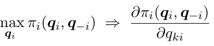

NOTE: contains mathematical notation; text above is the PDF text layer and symbols may be mis-extracted. Image shows the original.

*∂qki*

**equation / math rendering (image)**

NOTE: contains mathematical notation; text above is the PDF text layer and symbols may be mis-extracted. Image shows the original.

= 0*, ∀k*

**equation / math rendering (image)**

NOTE: contains mathematical notation; text above is the PDF text layer and symbols may be mis-extracted. Image shows the original.

In the market equilibrium, the aggregated supply of each type of content *k* across the

platform is the sum of streaming hours of all streamers, which can be expressed as

*Q<sup>∗</sup>*

**equation / math rendering (image)**

NOTE: contains mathematical notation; text above is the PDF text layer and symbols may be mis-extracted. Image shows the original.

*k* <sup>=</sup>

**equation / math rendering (image)**

NOTE: contains mathematical notation; text above is the PDF text layer and symbols may be mis-extracted. Image shows the original.

Z

**equation / math rendering (image)**

NOTE: contains mathematical notation; text above is the PDF text layer and symbols may be mis-extracted. Image shows the original.

*q<sup>∗</sup>*

**equation / math rendering (image)**

NOTE: contains mathematical notation; text above is the PDF text layer and symbols may be mis-extracted. Image shows the original.

*ki<sup>dF</sup><sup>i</sup>*

**equation / math rendering (image)**

NOTE: contains mathematical notation; text above is the PDF text layer and symbols may be mis-extracted. Image shows the original.

where *Fi* denotes the distribution of streamer *i* across the platform.

The primary goal of the regulator is to reduce the total supply of gambling content on the

platform by banning some gambling content in the livestreams. Without loss of generality, we

denote the supply of banned gambling content as *Q<sup>∗</sup>*

1<sup>,</sup> <sup>and</sup> <sup>any</sup> <sup>remaining</sup> <sup>unbanned</sup> <sup>gambling</sup>

6

Page 7

content as *Q<sup>∗</sup>*

2<sup>.</sup> <sup>In</sup> <sup>addition,</sup> <sup>we</sup> <sup>denote</sup> <sup>the</sup> <sup>total</sup> <sup>supply</sup> <sup>of</sup> <sup>gambling</sup> <sup>content</sup> <sup>as</sup> *<sup>Q</sup><sup>∗</sup>* gambling <sup>=</sup>

*Q<sup>∗</sup>*

**equation / math rendering (image)**

NOTE: contains mathematical notation; text above is the PDF text layer and symbols may be mis-extracted. Image shows the original.

by the policy and must revise their streaming plans. We denote the post-policy plan of streamer

*i* for content type *k* as ˜*q<sup>∗</sup>*

*ki* <sup>and</sup> <sup>the</sup> <sup>equilibrium</sup> <sup>supply</sup> <sup>of</sup> <sup>content</sup> *<sup>k</sup>* <sup>as</sup> <sup>e</sup>*<sup>Q</sup><sup>∗</sup>*

*k*<sup>.</sup> <sup>The</sup> <sup>banning</sup> <sup>policy</sup>

explicitly imposes the restriction that ˜*q<sup>∗</sup>*

However, not all gambling content faces ban on the platform, allowing streamers to continue

streaming unbanned gambling content, potentially even increasing the total supply of gambling

livestreams on the platform after the policy implementation. Therefore, the regulator assesses

the effectiveness of the banning policy by monitoring the changes in total supply of gambling

content on the platform:

∆%*Q<sup>∗</sup>*

**equation / math rendering (image)**

NOTE: contains mathematical notation; text above is the PDF text layer and symbols may be mis-extracted. Image shows the original.

gambling <sup>=</sup>

e*Q<sup>∗</sup>*

**equation / math rendering (image)**

NOTE: contains mathematical notation; text above is the PDF text layer and symbols may be mis-extracted. Image shows the original.

2 *<sup>−</sup><sup>Q</sup><sup>∗</sup>* gambling *Q<sup>∗</sup>*

**equation / math rendering (image)**

NOTE: contains mathematical notation; text above is the PDF text layer and symbols may be mis-extracted. Image shows the original.

gambling

=

e*Q<sup>∗</sup>*

**equation / math rendering (image)**

NOTE: contains mathematical notation; text above is the PDF text layer and symbols may be mis-extracted. Image shows the original.

**equation / math rendering (image)**

NOTE: contains mathematical notation; text above is the PDF text layer and symbols may be mis-extracted. Image shows the original.

1 <sup>+</sup>*<sup>Q</sup><sup>∗</sup>* 2 (1)

In contrast, the platform focuses on the changes in content production and consumption

after the policy implementation. On the supply side, content production is measured by the

changes in each type of content *k*,

∆%*Q<sup>∗</sup>*

**equation / math rendering (image)**

NOTE: contains mathematical notation; text above is the PDF text layer and symbols may be mis-extracted. Image shows the original.

*k* <sup>=</sup>

**equation / math rendering (image)**

NOTE: contains mathematical notation; text above is the PDF text layer and symbols may be mis-extracted. Image shows the original.

e*Q<sup>∗</sup>*

**equation / math rendering (image)**

NOTE: contains mathematical notation; text above is the PDF text layer and symbols may be mis-extracted. Image shows the original.

*k <sup>−</sup><sup>Q</sup><sup>∗</sup>*

**equation / math rendering (image)**

NOTE: contains mathematical notation; text above is the PDF text layer and symbols may be mis-extracted. Image shows the original.

*k Q<sup>∗</sup>*

**equation / math rendering (image)**

NOTE: contains mathematical notation; text above is the PDF text layer and symbols may be mis-extracted. Image shows the original.

*k*

**equation / math rendering (image)**

NOTE: contains mathematical notation; text above is the PDF text layer and symbols may be mis-extracted. Image shows the original.

(2)

On the demand side, the platform’s objective is defined by the total revenue generated by

all its steamers based on their current streaming plans,

*π*(*Q**<sup>∗</sup>*) =

**equation / math rendering (image)**

NOTE: contains mathematical notation; text above is the PDF text layer and symbols may be mis-extracted. Image shows the original.

Z

**equation / math rendering (image)**

NOTE: contains mathematical notation; text above is the PDF text layer and symbols may be mis-extracted. Image shows the original.

*πi*(*q**<sup>∗</sup>*

**equation / math rendering (image)**

NOTE: contains mathematical notation; text above is the PDF text layer and symbols may be mis-extracted. Image shows the original.

*i <sup>,</sup>**<sup>q</sup>**<sup>∗</sup>*

**equation / math rendering (image)**

NOTE: contains mathematical notation; text above is the PDF text layer and symbols may be mis-extracted. Image shows the original.

*−i*<sup>)</sup>*<sup>dF</sup><sup>i</sup>*

**equation / math rendering (image)**

NOTE: contains mathematical notation; text above is the PDF text layer and symbols may be mis-extracted. Image shows the original.

since the revenue is shared between the platform and the streamers. Therefore, the policy

impact on content consumption can be specified as

∆%*π* = *<sup>π</sup>*<sup>(</sup><sup>e</sup> *Q**<sup>∗</sup>*) *−π*(*Q**<sup>∗</sup>*)

**equation / math rendering (image)**

NOTE: contains mathematical notation; text above is the PDF text layer and symbols may be mis-extracted. Image shows the original.

*π*(*Q**<sup>∗</sup>*) (3)

**equation / math rendering (image)**

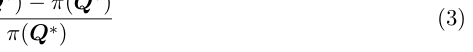

NOTE: contains mathematical notation; text above is the PDF text layer and symbols may be mis-extracted. Image shows the original.

where *π*(*·*) can be measured using various demand-side outcome variables, such as total hours

watched by viewers, in-stream bits and live donations, gifts, or subscriptions. In this paper, we

specifically focus on total hours watched by viewers and subscription revenue as the objective

functions of the platform.

The stylized model illustrates the potential misalignment among the incentives of the plat-

7

Page 8

form, the regulator and the content providers (streamers). While the effectiveness of the content

regulation is measured by Equation (1), the platform may primarily be concerned with the out-

comes described in (2) and (3). In scenarios of content self-regulation, the platform might inad-

vertently overlook some negative economic consequences measure by these outcomes. Moreover,

both targets are influenced by how streamers react to the banning policy, as streamers always

prioritize maximizing their own revenue. Therefore, our empirical target is to provide accurate

causal estimates that relate to the outcomes of interest as outlined in the above equations. To

elaborate on the policy’s impact, we also explore heterogeneous treatment effects by examining

the relationship between these outcome variables and the distribution of streamers *Fi* in Section

7.

### **4 Data**

In this section, we describe several novel data sources which we compile to study the effect of

the banning policy and to identify banned gambling content and streamers.

**Video streaming data on Twitch**. We created a novel high-frequency dataset of Twitch

streaming activities for the top 6,000 live streamers over five months, from August 1st, 2022,

to December 31st, 2022. We compiled the dataset from two sources. First, we obtained the top

6,000 streamers and their stream IDs from *sullygnome*. Based on the stream IDs, we obtained

data on streamed content, viewer count and follower count, recorded every 10 minutes, from

*twitchtracker* for the period from August 1st, 2022 to October 26th, 2022. Additionally, we

obtained all titles used in a stream and the timestamps of each title change. These data allow

us to restore each streamer’s status (online or offline), the start time and end time of the stream

and all activities within a stream. Second, for the period starting from October 26th, 2022,

we utilized the high-frequency streaming data on the same streamers collected by Yang and

Simonov (2024), through sending requests to the Twitch API every 15 minutes (See Appendix

A for details).<sup>3</sup> The combined dataset offers us a comprehensive view of the streaming activities

before and after the policy implementation.

For our main analyses, we aggregate streaming data to the weekly level for each streamer,

recording streaming metrics including total streaming hours, total hours watched by viewers,

weekly average viewership, and total streaming hours of each type of content within a week,

3We compile the first dataset from *sullygnome* and *twitchtracker*, since the second dataset does not cover data prior to the policy implementation. To ensure the quality of the first data source, we checked a few days of overlapping data from both sources and found them consistent, except that the first dataset occasionally misses stream title information and merges streams that live for a short duration into one stream.

8

Page 9

including online gambling, video games, and non-video game content.

We classify streamers based on how much online gambling content they have streamed

before the announcement of the banning policy on Sep 20th, 2022. Specifically, we assume

that streamers who almost never streamed online gambling content are unlikely to be affected

by the policy and should behave similarly to non-gambling streamers. Therefore, we set a

threshold such that any streamers who streamed less than 7.3 hours in total before the policy

implementation are removed from treated groups and added into the untreated group. The

threshold is selected as the first quartile of the distribution of total gambling hours before

the policy announcement. We have also examined our results based on alternative treatment

definitions (e.g., streamers are treated if they have streamed gambling content at least once

before policy announcement). our empirical findings are qualitatively the same across different

definitions, with minor differences in the magnitude of the effects.

To identify the causal effects of the policy, we exclude streamers who only broadcasted

either before or after the policy announcement. Additionally, we classify streamers into three

groups: banned, unbanned and untreated. We define *banned streamers* as those who had

streamed content from banned websites before the policy implementation, viewing them as

directly impacted by the policy. In contrast, *unbanned streamers* are defined as those who

streamed online gambling, but only from unbanned gambling websites. Since they streamed

content similar to what was banned, the policy might indirectly affect these streamers. Finally,

all streamers who never streamed online gambling are classified as *untreated streamers*.

However, while we have high-frequency data of all gambling livestreams during our studied

period, we do not observe which streams are about banned websites, and hence we are ignorant

about the list of banned streamers based on only the streaming dataset. We address this

challenge by leveraging three additional data sources: historical video clips, high-frequency

stream titles and in-stream chats logs. We provide further details of identifying banned content

and banned streamers in Section 5.

Table 1 reports the pre-treatment summary statistics at the streamer level. Our final

dataset comprises 158 banned streamers, 317 unbanned streamers and 4,626 untreated stream-

ers. Streamers across all groups exhibit similar streaming patterns, characterized by metrics

such as the total number of games played and average weekly livestreaming hours. We find that

banned streamers in general rely more on gambling streams than unbanned streamers, both in

terms of total hours spent on gambling streams and the proportion of gambling streams relative

to total livestreams.

9

Page 10

Table 1: Summary Statistics of Streamer Groups

|  | Banned | Unbanned | Untreated |
| --- | --- | --- | --- |
| Total Number of Games Played | 17 574 (20 945) . . | 20 076 (32 391) . . | 22 950 (32 320) . . |
| Hours of Livestreams by Week | 25 613 (19 301) . . | 21 175 (18 805) . . | 21 375 (18 571) . . |
| Hours of Gambling Streams by Week | 9 881 (13 789) . . | 5 181 (13 000) . . | 0 000 (0 000) . . |

NOTE: table converted from PDF layout to HTML text; cell boundaries are reconstructed. See PDF if exact alignment matters.

*Notes*. The table reports the streamer-level summary statistics for three groups of streamers. All observations are aggregated at the weekly level and calculated based on data from pre-treatment periods.

**Video game attributes**. To examine potential substitution patterns between online gambling

and video games featuring gambling-like content, we combine a rich game-level dataset with

the streamer-level panel dataset described above. Our game-level dataset is obtained from the

API of *IGDB*, one of the most extensive online video game databases owned by Twitch. For

each game, we obtain game attributes that encompass release date, genres, supporting gaming

platforms, available languages, age ratings, and the presence of remakes or expansions.

**Games with gambling-like content**. We classify all video games that were streamed at least

once in our streamer-level dataset based on the inclusion of gambling-like features. In light of

the absence of a comprehensive dataset containing information on this feature, we compile a list

of games with gambling-like content by investigating three primary sources: first, we extract

a roster of games featuring the concept of “Loot boxes” or “Gacha system” from *GiantBomb*.

These terms encapsulate the practice of randomly obtaining in-game items with predetermined

odds in video games, through the use of in-game currencies that can be purchased with real

money. Consequently, we suggest that engaging with these features mimics aspects of genuine

gambling experiences. Second, we employ text-mining techniques to scrutinize stream titles in

our high-frequency dataset. We collect content from streams with titles containing keywords

or phrases that are closely connected to gambling-like activities, such as “loot box opening”,

“insane pulls” or “getting shafted”, and we record games played under these titles. Third, we

identify games featuring gambling-like content by examining their PEGI and ESRB ratings, as

some rating details disclose whether loot boxes are present in the games. We manually combine

information from all three sources. By synthesizing data from all three sources, we compile a list

of 464 unique video game titles within our streaming data identified as containing gambling-like

features.

In addition to these games, we categorize other streaming content into three groups: online

gambling, games without loot boxes, and non-gaming content such as chatting or outdoor

activities. Specifically, the online gambling category encompasses all streams labeled under

10

Page 11

“Slots” (the largest gambling category on Twitch), “slots!”, “Blackjack”, “Casino” and “Virtual

Casino”. As the policy ban did not cover all online gambling content, we provide a detailed

discussion in Section 5 of our methods for detecting banned versus unbanned content within

online gambling streams.

**Video data**. We collect all video clips from online gambling streams of individual streamers

before the policy implementation using Twitch API’s get clips endpoint. We use these video

clips to identify the presence of banned content and therefore the latent treatment status of the

streamers. We discuss this process in detail in Section 5.1.

**Chat logs data**. We obtained in-stream chat logs from *Streams Charts*, whose data of coverage

aligns with the coverage of our high-frequency streaming data. For each stream of a streamer,

we observe the chat messages (texts), the account names and IDs of the chatters who posted

the messages, and the timestamps of when the messages were posted. We use the chats as an

additional source to identify the latent treatment status of streamers (which we detail in Section

5.3). Additionally, we use chatters (i.e., individual registered viewers on Twitch) to construct

valid treated and untreated groups for demand-side analysis (which we detail in Section 8).<sup>4</sup>

In Appendix A, we show that chatters, although being a subset of all viewers in streams, is a

reliable proxy for overall viewership base in streams.

**Subscriptions and revenue data**. We collect from *Streams Charts* the number of subscribers

gained per stream of a streamer and its breakdown, which includes all types (i.e., new subscrip-

tions, re-subscriptions and gifted subscriptions) and tiers (i.e., Tier 1, Tier 2, Tier 3).<sup>5</sup> We use

the data for revenue analysis in Section 8.

**Other streamer-level data**. For each streamer, we collect their country and city of residence,

and their histories of prohibition on Twitch (i.e., the number of channel prohibitions, the dates

and the duration of each prohibition) from *Streams Charts*. We use the residence information

as one source to match video clips to streams (see discussions in Appendix B.1). Addition-

**Website traffic data.** We obtain *SimilarWeb*’s website traffic data from *Dewey*, which con-

tains monthly total traffic on a domain and subdomain level starting from September 2018 with

4The Twitch API only has viewer count in streams, but not the list of individual viewers in streams. 5This dataset is only available for streamers who enabled channel tracking. Streams Charts do not count subscriptions when a channel is offline and do not track auto-renewed subscriptions unless the viewer notifies auto-renewal by clicking appropriate button in chats. While we use this subscription data for revenue discussion, we note its limitation of possibly not being fully representative, as streamers self-select into disclosing this information.

11

Page 12

a breakdown by device type. We use the data to examine whether banned gambling websites

have experienced sudden traffic changes due to the policy (see Section 9).

#### **4.1 Descriptive Evidence**

We first present some descriptive evidence on the impact of implementing banning policy. Fig-

the vertical dashed lines show the date of announcing the policy (September 20th, 2022) and

implementing the policy (October 18th, 2022). Both treated groups show downward trends in

weekly streaming hours after the policy implementation, whereas the weekly streaming hours of

streamers in the untreated group are relatively more stable over time. In addition, the seasonal

trend has a similar effect on all three groups both before and after the policy implementation.

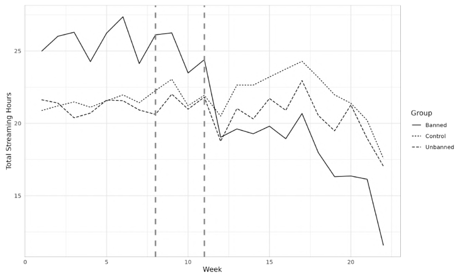

NOTE: figure/graphic rendered as an image from the PDF; its content is not machine-readable text. Caption (if any) follows as the next block.

time. As expected, we observe that banned streamers significantly reduced weekly streaming

hours of gambling after the policy implementation. Moreover, we find that unbanned streamers

also reduced their supply of gambling livestreams, but with a much smaller magnitude. This

trend provides some preliminary evidence that the policy also had impact on streamers who

12

Page 13

in supply of gambling livestreams during the weeks between the policy announcement and

implementation, which may be due to that the announcement temporarily increased demand of

gambling content after the policy was announced.

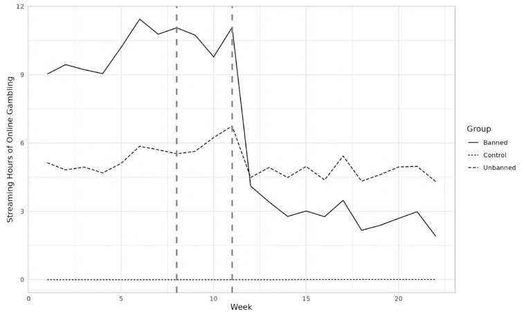

NOTE: figure/graphic rendered as an image from the PDF; its content is not machine-readable text. Caption (if any) follows as the next block.

To summarize, our descriptive evidence suggests that streamers who had streamed gam-

bling content before the policy announcement decreased both their total livestreams and their

livestreams of gambling content, whether they were directly or indirectly affected. Nonetheless,

the details of the policy’s impact, such as the actual magnitudes, persistence or heterogeneous

treatment effects, remain unclear.

### **5 Detection of Banned Content and Streamers**

As discussed in Section 4, our streamer-level data does not specify whether a gambling stream

was on banned or unbanned websites, nor does it indicate whether a streamer has streamed

banned gambling content. Therefore, we need to leverage additional data sources to address

these issues of missing information. In this section, we describe how we systematically detect

production of banned gambling content, identify treated groups and measure the intensity of

banned content production of each streamer. We combine multiple methods and data sources

13

Page 14

including videos, stream titles and chat logs to detect banned streams, which we overview below

and describe in more details in Appendix B.

#### **5.1 Identifying Banned Content From Video Clips and VODs**

First, we construct a list of streamers who had history of streaming gambling content at least

once before the policy implementation. We fetch URLs of all past gambling video clips of a

streamer pre-policy from Twitch API.<sup>6</sup> Clipping (up to 60 seconds) is a functionality enabled by

Twitch that allows both the streamer and any logged-in viewer to capture and share moments

from a streamer’s livestreams. Thus, we treat clips as random stream moments, for which we

can use as one source to check any existence of banned content production by streamers.

We identify banned content from video clips using a procedure as shown in Figure 3. The

procedure involves three key steps: In **step 1**, we download all historical video clips of a streamer

(in total over 4TB in size) from clip URLs using *youtube-dl* package (which also supports twitch

video downloads). In **step 2**, we decompose each video into a sequence of frames. To optimize

the processing workload, we sample three frames from each video, covering the start, middle

and end of each clip for content analysis. This strategy is effective since clipped videos are under

60 seconds with minimal scene changes, and thus sampling reduces the total number of frames

that need to be analyzed without losing critical information. Finally, in **step 3**, we transform

each sampled frame to grayscale<sup>7</sup> and use Google’s *Tesseract-OCR* engine to extract all texts

from each frame. We check the extracted texts against all banned websites’ keywords and use

a restrictive criterion by classifying a clip as only containing banned content if keywords are

detected in all 3 frames of a video (or unbanned if absent in all frames), to ensure accuracy of

the classification.

We complement our analysis on video clips with additional Video on Demand (VOD) posted

on YouTube that are available for a few prominent streamers, including xQc, Adin Ross and

ItsSliker. VODs are archives of content previously streamed live on Twitch and can span several

hours (if unedited).<sup>8</sup> For these long VODs, we manually inspect them to identify the presence

(and time of presence) of the banned content. We match these videos (video clips and VODs) to

their original streams to compile a list of gambling streams and streamers with banned content.

6We restrict our analysis to content that was produced between August 1st and October 17th, 2022 (inclusive) to align with the coverage of our stream-level data.

7Grayscale conversion is a common pre-processing step in video analysis. It helps reduce reduce distractions caused by color variance and enhances the focus on text detection.

8Although VODs on Twitch are only saved up to 2 months for Partners, streamers can enable VOD storage and export their videos to other platforms, such as YouTube, by linking with their Twitch accounts. For example, xQc’s VODs can be found on YouTube via https://www.youtube.com/@xqcgames3433/videos.

14

Page 15

The detailed process of our matching procedure is provided in Appendix B.1.

We note that not all streamers have video clips or VODs accessible (e.g., some streamers

may have disabled the clipping functionality on their streams). Therefore, we propose a few

additional data sources and methods to help us identify the latent treatment status of streamers,

which we detail next.

Figure 3: Banned Content Detection Using Videos

[figure not shown]

NOTE: figure/graphic rendered as an image from the PDF; its content is not machine-readable text. Caption (if any) follows as the next block.

*Notes.* This figure shows the procedure for which we detect banned gambling content from videos.

#### **5.2 Identifying Banned Content From Stream Titles**

Twitch streamers sometimes put an exclamation point followed by a keyword (e.g., !Stake,

!Roobet) in stream titles. These are commands that viewers can type into a channel’s chat

to interact with the streamer, and the commands will trigger a bot to respond with the re-

quired information. When names of the banned websites are used as keywords in gambling

streams, viewers can automatically receive these websites’ referral links and streamers can earn

commissions from whenever a viewer signs up on the gambling websites and uses their services.<sup>9</sup>

Recognizing this user habit, we leverage our high-frequency streaming data, which captures

stream titles and the games streamed at every 10-minute intervals prior to the policy implemen-

tation, as an additional source for identifying banned content in gambling streams. We define

a stream as containing banned content when both of the following conditions are met: (1) the

presence of “!” followed by banned website keywords in stream titles, and (2) the game being

streamed is categorized as online *gambling* content.

9This is common practice within the community of gambling content streams. It became even more prevalent ever since Twitch banned the sharing of links to gambling sites in 2021, in response to concerns from the National Council on Problem Gambling and its allies regarding the risk of under-age gambling and gambling addiction. Source: https://www.ncpgambling.org/news/ncpg-responds-to-twitch-banning-gambling-sites-links/.

15

Page 16

We demonstrate the validity of this approach for detecting additional banned content (and

streamers) in Table B.2.1. Our findings show that *non-gambling* streamers typically do not

include such commands in their stream titles. In addition, since these commands are often used

to enhance viewer engagement in chats, streamers have low incentives to include commands

in titles that do not align with their streaming content, as it could risk reducing engagement.

Furthermore, many streamers in our dataset are top streamers who treat streaming as a full-

time job, thereby reducing the likelihood of of inappropriate use of commands. Overall, our

approach is more conservative compared to defining a stream as containing banned content

solely based on the presence of banned website names in stream titles (see Appendix B.2 for

additional discussions). This approach ensures the accuracy of classification while minimizing

the risk of misclassifying unbanned content as banned (i.e. minimizing false positives).

We note that, however, that not all streamers include such commands when streaming

banned content. Therefore, we complement our banned content detection with a third source -

chats logs, which we detail next.

Table 2: Banned Content Detection Using Stream Title

|  | Streamers with Gambling Content | Streamers without Gambling Content |
| --- | --- | --- |
| Total Number | 475 | 4626 , |
| Banned Referrals in Any Stream Titles | 52 | 2 |
| Banned Referrals in Gambling Stream Titles | 50 | 0 |

NOTE: table converted from PDF layout to HTML text; cell boundaries are reconstructed. See PDF if exact alignment matters.

*Notes*: This table shows the number of streamers who were detected using referral links to banned websites in any stream titles versus only in gambling stream titles in the two groups. We detect banned referrals by checking instances of an exclamation point followed by a banned website keyword in stream titles.

#### **5.3 Identifying Banned Content From Chat Logs**

We use chats logs as the third additional source to predict the presence of banned content for

streams that neither have OCR nor commands in stream titles. To achieve this, we need to

construct ground truth chat samples by identifying ground truth streams that feature banned

and unbanned content, respectively. We use multiple criteria to construct the samples.

For the banned ground truth chats, we use chats from streams that meet the following two

criteria: (1) the gambling streams must have video clips that match to it where we have already

found the presence of banned content in all three sampled frames of a video using OCR, and

(2) the gambling streams must have banned websites’ referral links included in stream titles.

16

Page 17

We note that while each source alone can be treated as the ground truth, combining the two

criteria together ensures high quality of the ground truth sample.

For the unbanned ground truth chats, we use chats from streams that satisfy all three of

the following criteria: (1) the gambling streams must have video clips with no banned website

names detected in the 3 sampled frames of a video using OCR, (2) the streams that come

from streamers who have no history of streaming banned content based on OCR detection on

all their pre-policy gambling stream video clips, (3) the gambling streams must have neither

banned referral links nor banned keywords featured in stream titles.

We note that using multiple criteria for constructing the unbanned ground truth is necessary

because the absence of banned content in all 3 frames of a video as detected by OCR is necessary

but not sufficient to classify a stream as unbanned. For example, a clip might show content from

a banned website that OCR cannot detect if it does not feature the banned website’s logo or

keyword in any frame. However, if OCR detects banned content, it confirms that the streamer

indeed streams banned content. We provide more discussions regarding the robustness of our

ground truth sample construction approach in Appendix B.3.

Using these stringent criteria, we obtain a ground truth chats sample, covering 534 banned

streams and 821 unbanned streams, which serves as the basis for our stream classification below.

**Inference Step**. Based on industry knowledge and observed practices on Twitch, we hypoth-

esize that banned streams will contain a higher proportion of referral links to banned websites.

This is because streamers who engage in promoting banned content often use chat bots to au-

tomatically respond to viewers who required referral links to these websites,facilitating viewer

access.

We test this hypothesis by first checking the summary statistics (Table 3) of banned and

unbanned chats samples. We find that banned gambling streams contain 100 times more referral

links of banned websites — despite having fewer total chats. Additionally, banned gambling

streams have 130 times more unique viewers who posted banned referral links in chats. Both

statistics suggest that there is a difference in referral links of banned websites in chats between

banned and unbanned groups.

Based on the summary statistics, we consider a test statistic of the number of banned referral

links per hour. Figure 4 shows the density and distribution of number of referral links in banned

and unbanned stream samples. We observe that the distribution of referral links in unbanned

streams has a huge mass at zero, where banned streams have a significantly larger probability of

17

Page 18

containing more than one referral links per hour. The difference in the distributions is further

supported by the right panel, where we show that the distribution of referral links in banned

streams first-order statistically dominates that in unbanned streams. This evidence supports

that using referral links of banned websites in chats could be a valid criteria for identifying

banned and unbanned streams.

Next, we evaluate the distributional difference formally by conducting a bootstrapped Kolmogorov-

Smirnov test for 5,000 repetitions, deriving the KS statistics in each bootstrap sample using the

function from Bootstrapped KS2 Tester, based on 534 streams of both banned and unbanned

content. Figure 5 depicts the distribution of bootstrapped KS statistics, where this statistic is

defined as the maximum absolute difference between two empirical distributions. Since the av-

erage p-value is significantly less than the usual nominal level, we always reject the null that the

numbers of referral links follow the same distribution in banned and unbanned streams. More-

Therefore, we conclude from the inference step that a threshold-based classification is sufficient

for detecting banned streams in our research, where our target is to find an optimal threshold

value for the classification method in the prediction step.

Figure 4: Distributions of Referral Links per Hour in Banned and Unbanned Gambling Streams

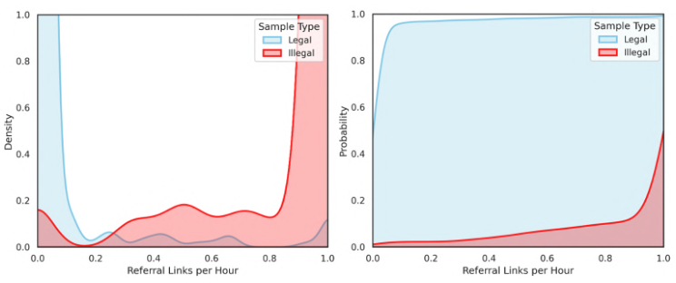

NOTE: figure/graphic rendered as an image from the PDF; its content is not machine-readable text. Caption (if any) follows as the next block.

*Notes.* This figure shows the density and distribution of referral links per hour in banned (red) and unbanned (blue) gambling streams, where we right-censored the number of referral links per hour at one in both panels. The left panel displays the density of referral links per hour, highlighting that banned gambling streams have a significantly higher probability of containing a large number of referral links compared to unbanned streams. The right panel shows the cumulative distributions of referral links, indicating that the distribution of referral links in banned streams first-order statistically dominates that in unbanned streams. These visualizations support our hypothesis that banned streams has a very distribution of referral links, making the number of referral links per hours a robust criterion for distinguishing between banned and unbanned gambling streams.

18

Page 19

Table 3: Summary Statistics of Ground Truth Chats Samples

|  | Banned Gambling Streams | Unbanned Gambling Streams |
| --- | --- | --- |
| Total Chats | 4031759 , , | 4305627 , , |
| Unique Streams | 534 | 821 |
| Unique Streamers | 39 | 99 |
| Unique Viewers | 199450 , | 258913 , |
| Banned Referrals in Chats | 18872 , | 152 |
| Viewers Posting Banned Referrals in Chats | 12155 , | 92 |

NOTE: table converted from PDF layout to HTML text; cell boundaries are reconstructed. See PDF if exact alignment matters.

*Notes*: This table presents the summary statistics of the ground truth banned and unbanned chat samples.

Figure 5: Distribution of Bootstrapped KS Statistics in Inference Step

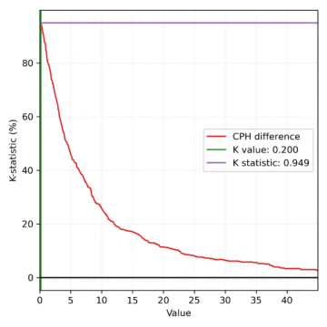

NOTE: figure/graphic rendered as an image from the PDF; its content is not machine-readable text. Caption (if any) follows as the next block.

*Notes.* This figure shows the distribution of Bootstrapped Kolmogorov-Smirnov statistics.

**Prediction Step**. To find an optimal threshold that jointly minimizes Type I and Type II errors

for classification, we propose to use grid search with 10-fold cross validation.<sup>10</sup> To achieve this,

we first correct the imbalance in our ground truth samples (534 banned versus 821 unbanned

streams) by implementing a *random undersampling* (Breiman, 2017) during the training phase

of each cross validation fold. Next, we employ a 10-fold cross validation with grid search and

evaluate thresholds in-sample to identify the optimal threshold.<sup>11</sup> We choose a threshold of 0.3,

which jointly minimizes Type I and Type II errors in-sample.<sup>12</sup>

The threshold-based approach demonstrates a strong capability to distinguish between two

sample groups. On average there is a 93% probability that the method is able to distinguish

10In our context, type I error is defined as incorrectly classifying an banned stream as banned, and type II error is defined as incorrectly classifying a banned stream as unbanned.

11We set the range of grid search to be from 0 to 2, with increments of 0.05. 12A threshold of 0.3 also achieves good performance on other measures. See Appendix B.4 for detailed discussions.

19

Page 20

between banned and unbanned samples (See Figure B.4.1 in Appendix for confusion matrices

across folds, and Table B.4 for detailed in-sample and out-sample performance.)

**Identification of Treated Groups Using All Sources**. We combine detection results from

all three approaches (video clips, stream titles and chat logs) described in this section and

collect a list of banned streams. Then, we use these identified banned streams to classify

treated streamers into banned and unbanned groups.

### **6 Empirical Strategy**

In this section, we outline the three main empirical strategies for estimating the causal effects

of the banning policy. Our primary goal is to assess how streamers whose content were banned

changed their production decisions of livestreaming, and how this affected the demand for their

livestreams and their revenue. Additionally, we are interested in whether these impacts also

applied to streamers who streamed online gambling content under the threat of a future ban.

These policy impacts inform us about the effectiveness of the content regulation and reveal any

potential side effects that might not align with the platform’s incentives. In Section 4.1, we

show that all groups of streamers exhibit similar trends in both average log weekly streaming

hours and average log weekly streaming hours of online gambling. Therefore, we use the classic

difference-in-differences (DiD) framework to estimate the policy impact as the average treatment

effect on the treated (ATT).

Nonetheless, we face several identification challenges: first, the classic two-way fixed effect

DiD model usually assumes for parallel trend assumption (PTA) between streamers with dif-

ferent treatment status. Although our descriptive evidence suggests that different groups of

streamers tend to follow similar trends over time, the assumption still remains questionable

because streamers might pursue strategic changes in their streaming plan in response to the

policy implementation. The potential strategic interaction may potentially affect both supply-

and demand-side outcome variables in our identification. Second, the policy may induce stream-

ers to change their streaming content, leading viewers to switch to other channels to fulfill their

interests. Consequently, the banning policy may generate equilibrium spillovers to the observed

demand of streamers, resulting in a upward bias in the DiD estimates of demand-side variables

or even potential bias in supply-side estimates. Therefore, using untreated streamers who share

viewers with treated streamers as the untreated group leads to potential violation of the Stable

20

Page 21

Unit Treatment Values Assumption (SUTVA). Finally, since there is no pure randomization for

the groups of treated and untreated streamers, these streamers may have systematic differences

in both observed and unobserved factors, leading to potential bias in two-way fixed effect DiD

estimates.

To overcome these identification challenges, we start with the classic two-way fixed effect DiD

model as the baseline, and subsequently turn to discuss two alternative empirical approaches in

the main analysis. To alleviate concerns over the violation of the parallel trend assumption, we

adopt the synthetic difference-in-differences (SynthDiD) estimator proposed by Arkhangelsky

et al. (2021); Berman and Israeli (2022). To address potential systematic differences between

different groups of streamers, we apply the doubly-robust estimator of group-time average treat-

ment effects proposed by Callaway and Sant’Anna (2021), which utilizes generalized propensity

scores to balance units between the treated and untreated groups. Finally, to ensure our es-

timates are unbiased under potential violations of SUTVA, we leverage network analysis on

chat logs to evaluate the extent of overlapping viewership between streamers. This allows us to

reconstruct the treated and untreated groups based on a selected subset of streamers and use

them for additional checks of validity of our estimated treatment effects.

#### **6.1 Two-way Fixed Effect DiD**

We begin with the classic DiD model including streamer and week fixed effects:

*yit* = *αi* + *γt* + *β*1 *·* Banned*i ·* Post*t* + *β*2 *·* Banned*i ·* Announcement*t*

**equation / math rendering (image)**

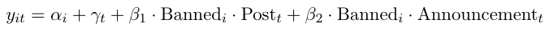

NOTE: contains mathematical notation; text above is the PDF text layer and symbols may be mis-extracted. Image shows the original.

+ *β*3 *·* Unbanned*i ·* Post*t* + *β*4 *·* Unbanned*i ·* Announcement*t* + *εit*

(4)

where Banned*i* and Unbanned*i* are indicators of the two treated groups, and Post*t* and Announcement*t*

are indicators of post-treatment periods and periods between the policy announcement and the

policy implementation. On the supply side, the dependent variable *yit* includes supply-side out-

comes including log of weekly streaming hours of each type of streaming content we described in

Section 4 and log of total weekly streaming hours. On the demand side, we use log of total hours

watched by all viewers, and three tiers of subscriptions as dependent variables. Our primary

focus lies in the estimated values of *β*1 and *β*3, which capture the policy’s effects on banned

streamers and unbanned streamers after the policy implementation.

Additionally, we leverage a flexible event-study model to estimate the time-varying treatment

effects. Compare to our baseline specification with 3 time periods, the event-study estimates

21

Page 22

provide more insights into the persistence of the treatment effects. Following the empirical

suggestions from Freyaldenhoven et al. (2021), we normalize the causal estimate one period

ahead of the policy implementation to zero, and report both the point-wise confidence intervals

as well as the uniform sup-*t* confidence bands for the event-time path of the treatment effects.

#### **6.2 Synthetic DiD**

Arkhangelsky et al. (2021) introduced Synthetic DiD (SynthDiD) method, which combines the

synthetic control method (Abadie and Gardeazabal, 2003; Abadie et al., 2010) with classic DiD

regression, whereas it has been used commonly in marketing research involving panel studies,

e.g. Berman and Israeli (2022). SynthDiD addresses the identification challenge related the

parallel trend assumption by leveraging the idea of synthetic control to construct an “artificial”

parallel trend. The method is implemented in two steps: in Step 1, we determine a set of unit

weights ( ˆ*wi*)*<sup>N</sup>*

*i*=1 <sup>and time weights (ˆ</sup>*<sup>λ</sup><sup>t</sup>*<sup>)</sup>*<sup>T</sup>*

*t*=1 <sup>to align pre-treatment trends between the treated group</sup>

and the untreated group. The unit weights are used to prioritize the role of untreated units that

are more similar to the treated units, while the time weights are used to prioritize time periods

such that the corresponding time trends closely resemble those from the pre-treatment periods.

In Step 2, we estimate ATT based on the following specification including both individual and

time fixed effects:

(<sup>ˆ</sup>*β*<sup>SynthDiD</sup>*,* ˆ*α,* ˆ*γ*) = arg min

*β,α,γ*

**equation / math rendering (image)**

NOTE: contains mathematical notation; text above is the PDF text layer and symbols may be mis-extracted. Image shows the original.

(X

**equation / math rendering (image)**

NOTE: contains mathematical notation; text above is the PDF text layer and symbols may be mis-extracted. Image shows the original.

*i*

**equation / math rendering (image)**

NOTE: contains mathematical notation; text above is the PDF text layer and symbols may be mis-extracted. Image shows the original.

X

**equation / math rendering (image)**

NOTE: contains mathematical notation; text above is the PDF text layer and symbols may be mis-extracted. Image shows the original.

*t*

**equation / math rendering (image)**

NOTE: contains mathematical notation; text above is the PDF text layer and symbols may be mis-extracted. Image shows the original.

(˜*yit −αi −γt −β*<sup>SynthDiD</sup>

**equation / math rendering (image)**

NOTE: contains mathematical notation; text above is the PDF text layer and symbols may be mis-extracted. Image shows the original.

*j · Dj,it*) ˆ*wi*<sup>ˆ</sup>*λt*

**equation / math rendering (image)**

NOTE: contains mathematical notation; text above is the PDF text layer and symbols may be mis-extracted. Image shows the original.

)

**equation / math rendering (image)**

NOTE: contains mathematical notation; text above is the PDF text layer and symbols may be mis-extracted. Image shows the original.

(5)

whereas *β*<sup>SynthDiD</sup>

*j , j* = 1*,* 2*,* 3*,* 4 is the SynthDiD counterpart of the DiD estimator *βj* in our

baseline specification, and *Dj,it* denotes the corresponding interaction term of group and time

indicators. To adopt this estimator under our specification with two group indicators and two

time indicators, we follow the suggestion from Clarke et al. (2023) by first partialing out all

interactions of indicators other than *Dj,it*, then performing the SynthDiD estimator based on

the residual ˜*yit*.

#### **6.3 Doubly-Robust Estimator of Group-Time ATT**

To tackle the challenges associated with selection in our identification, we utilize the doubly-

robust estimator for group-time average treatment effects introduced by Callaway and Sant’Anna

(2021). This method features inverse propensity score weighting that utilizes generalized propen-

22

Page 23

sity score, which is defined as

*Pg,s*(*X*) = *P*(*Gg* = 1 *| X, Gg* + *C* = 1) (6)

**equation / math rendering (image)**

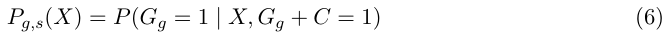

NOTE: contains mathematical notation; text above is the PDF text layer and symbols may be mis-extracted. Image shows the original.

where *Gg* is the indicator that the unit is first treated at time *g*, and the second condition

ensures that the unit is either in group *g* or in the never-treated group indicated by *C*. Since

all units are treated at the same time and there is a group of streamers who never receive the

treatment, our identification relies on the following conditional parallel trend assumption based

on the ”Never-Treated” Group:

E[*yt*(0) *−yt−*1(0) *| X, Gg* = 1] = E[*yt*(0) *−yt−*1(0) *| X, C* = 1] a.s. (7)

**equation / math rendering (image)**

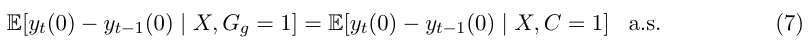

NOTE: contains mathematical notation; text above is the PDF text layer and symbols may be mis-extracted. Image shows the original.

The average treatment effect of the treated for cohort *g* at time *t* is non-parametrically

identified as

*β*(*g, t*) = *βDR*(*g, t*; *τ*) = E

**equation / math rendering (image)**

NOTE: contains mathematical notation; text above is the PDF text layer and symbols may be mis-extracted. Image shows the original.

**equation / math rendering (image)**

NOTE: contains mathematical notation; text above is the PDF text layer and symbols may be mis-extracted. Image shows the original.

**equation / math rendering (image)**

NOTE: contains mathematical notation; text above is the PDF text layer and symbols may be mis-extracted. Image shows the original.

**equation / math rendering (image)**

NOTE: contains mathematical notation; text above is the PDF text layer and symbols may be mis-extracted. Image shows the original.

 *Gg* E(*Gg*) *<sup>−</sup>*

**equation / math rendering (image)**

NOTE: contains mathematical notation; text above is the PDF text layer and symbols may be mis-extracted. Image shows the original.

*Pg*(*X*)*C* 1*−Pg*(*X*)

**equation / math rendering (image)**

NOTE: contains mathematical notation; text above is the PDF text layer and symbols may be mis-extracted. Image shows the original.

E

**equation / math rendering (image)**

NOTE: contains mathematical notation; text above is the PDF text layer and symbols may be mis-extracted. Image shows the original.

*Pg*(*X*)*C* 1*−Pg*(*X*) (*yt −yg−τ−*1 *−mg,t,τ*(*X*))

**equation / math rendering (image)**

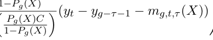

NOTE: contains mathematical notation; text above is the PDF text layer and symbols may be mis-extracted. Image shows the original.

**equation / math rendering (image)**

NOTE: contains mathematical notation; text above is the PDF text layer and symbols may be mis-extracted. Image shows the original.

**equation / math rendering (image)**

NOTE: contains mathematical notation; text above is the PDF text layer and symbols may be mis-extracted. Image shows the original.

**equation / math rendering (image)**

NOTE: contains mathematical notation; text above is the PDF text layer and symbols may be mis-extracted. Image shows the original.

 (8)

whereas *mg,t,τ*(*X*) = E[*yt −yg−τ−*1 *| X, C* = 1]. Finally, the aggregate treatment effect <sup>ˆ</sup>*β<sup>DR</sup>* is

**equation / math rendering (image)**

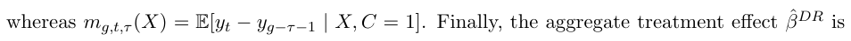

NOTE: contains mathematical notation; text above is the PDF text layer and symbols may be mis-extracted. Image shows the original.

estimated by averaging over all <sup>[</sup> ATT(*g, t*) based on their groups. Through leveraging the gener-

alized propensity scores, this estimator effectively addresses the aforementioned selection issue.

Moreover, it enables us to estimate the time-varying average treatment effects and compare

them with event-study estimates. We omit more technical details and refer readers to Callaway

and Sant’Anna (2021).

Finally, even with the use of advanced econometric tools, the identification challenge posed

by potential violation of SUTVA still remains. To address this issue, we leverage network anal-

ysis to construct comparable groups of treated and untreated streamers for our identification.

We discuss this approach in detail in Section 8.2.

### **7 Supply-Side Results**

In this section, we report DiD, SynthDiD and the doubly-robust estimators of the ATT of

banning policy on supply-side outcome variables. For clarity, we interpret our results based on

the SynthDiD estimates.

#### **7.1 Content Creation of Gambling and Non-Gambling Livestreams**

Table 4 reports the impact of the banning policy on gambling livestreams. We find that the

supply of gambling livestreams decreased across the platform after the policy implementation,

with banned streamers reducing their gambling streams by 63.2% (= exp (*−*1*.*001) *−*1) and

unbanned streamers reducing theirs by 12.2%. These estimates have two implications: first, in

addition to the banned gambling content, banned streamers reduced livestreams of unbanned

gambling content as well as banned gambling content. This is because the overall share of

banned streams among all gambling streams for these streamers is 55.8%, which is smaller

than the 63.2% reduction caused by the policy. Second, even though Twitch only banned four

websites, streamers not directly affected by the policy also reduced their creation of gambling

content. Therefore, the banning policy was successful in regulating the overall supply of online

gambling content across the platform.

Table 4: The Impact of Twitch’s Ban Policy on Gambling Content Creation

|  | log(Gambling hours + 1) |  |
| --- | --- | --- |
|  | TWFE | SynthDiD ATTGT |
| Banned (β 1) | 1 022*** - . (0 089) . | 1 001*** 1 023*** - . - . (0 082) (0 102) . . |
| ∆% | 64 0% - . | 63 2% 64 0% - . - . |
| Unbanned (β 3) | 0 116** - . (0 049) . | 0 130*** 0 242*** - . - . (0 043) (0 049) . . |
| ∆% | 11 0% - . | 12 2% 21 5% - . - . |
| Streamer FE | ✓ | ✓ ✓ |
| Week FE | ✓ | ✓ ✓ |
| Observations | 112 222 , | 112 222 112 222 , , |
| Mean dependent variable | 1 131 . | 1 131 1 131 . . |

NOTE: table converted from PDF layout to HTML text; cell boundaries are reconstructed. See PDF if exact alignment matters.

*Notes*. All standard errors are clustered at the streamer level. The mean dependent variable is calculated based on observations of all treated streamers before the policy announcement. FE, fixed effect. Significance level: **p <* 0*.*1; ***p <* 0*.*05;****p <* 0*.*01

To answer the question that whether potential substitution between online gambling and

gambling-like features in video games weakened the effect of banning policy on Twitch, we re-

port estimated treatment effect on the supply of video games featuring gambling-like elements

in Table 5. The overall non-significant estimates suggest that on the supply side, gambling

streamers did not treat video games with gambling-like features as a means to pursue to main-

tain their viewership. Our findings provide new evidence on the similarity between traditional

gambling and gambling-like activities in video games, indicating that the potential substitution

between these two types of content might not be as interchangeable as some policymakers have

presumed.

Table 5: The Impact of Twitch’s Ban Policy on Content Creation of Video Games with Gambling-like Features

|  | log(LootBox Games + 1) |  |  |
| --- | --- | --- | --- |
|  | TWFE | SynthDiD | ATTGT |
| Banned (β 1) | 0 012 . (0 065) . | 0 021 . (0 054) . | 0 089 . (0 076) . |
| ∆% | - | - | - |
| Unbanned (β 3) | 0 046 - . (0 046) . | 0 054 - . (0 036) . | 0 096 - . (0 053) . |
| ∆% | - | - | 9 1% - . |
| Streamer FE | ✓ | ✓ | ✓ |
| Week FE | ✓ | ✓ | ✓ |
| Observations | 112 222 , | 112 222 , | 112 222 , |
| Mean dependent variable | 1 487 . | 1 487 . | 1 487 . |

NOTE: table converted from PDF layout to HTML text; cell boundaries are reconstructed. See PDF if exact alignment matters.

*Notes*. All standard errors are clustered at the streamer level. The mean dependent variable is calculated based on observations of all streamers before the policy announcement. FE, fixed effect. Significance level: **p <* 0*.*1; ***p <* 0*.*05;****p <* 0*.*01

Finally, we turn to examine the policy’s impact on total content creation on the treated

streamers. Estimates in the first three columns of Table 6 show that both banned and unbanned

streamers reduced their total streaming hours after the policy implementation. However, were

the reductions solely due to the decrease in gambling content creation for both banned and

unbanned streamers, as we observe in Table 4? We further investigate the sources of the decline

in content creation and find that, relative the untreated group streamers, both group of treated

from the platform, as the banning policy reduced non-targeted content creation among both

directly and indirectly affected streamers. Since video games without gambling-like features

encompass a wide variety of game genres, this implies that the policy may inadvertently harm

the diversity of content on the livestreaming platform.

Table 6: The Impact of Twitch’s Ban Policy on Gambling Livestreams on Total Streaming Hours and Streaming Hours of Games without Gambling Features

|  | log(Streaming hours + 1) |  |  | log (Other games + 1) |  |  |
| --- | --- | --- | --- | --- | --- | --- |
|  | TWFE | SynthDiD | ATTGT | TWFE | SynthDiD | ATTGT |
| Banned (β 1) | 0583*** - . (0084) . | 0585*** - . (0075) . | 0543*** - . (0096) . | 0146*** - . (0040) . | 0149*** - . (0032) . | 0172*** - . (0050) . |
| ∆% | 442% - . | 443% - . | 419% - . | 135% - . | 138% - . | 156% - . |
| Unbanned (β 3) | 0182*** - . (0044) . | 0194*** - . (0040) . | 0242*** - . (0050) . | 0133*** - . (0032) . | 0130*** - . (0026) . | 0075** - . (0036) . |
| ∆% | 166% - . | 176% - . | 215% - . | 125% - . | 122% - . | 72% - . |
| Streamer FE | ✓ | ✓ | ✓ | ✓ | ✓ | ✓ |
| Week FE | ✓ | ✓ | ✓ | ✓ | ✓ | ✓ |
| Observations | 112222 , | 112222 , | 112222 , | 112222 , | 112222 , | 112222 , |
| Mean dependent variable | 2587 . | 2587 . | 2587 . | 1079 . | 1079 . | 1079 . |

NOTE: table converted from PDF layout to HTML text; cell boundaries are reconstructed. See PDF if exact alignment matters.

*Notes*. All standard errors are clustered at the streamer level. The mean dependent variable is calculated based on observations of all streamers before the policy announcement. FE, fixed effect. Significance level: **p <* 0*.*1; ***p <* 0*.*05; ****p <* 0*.*01

#### **7.2 Supply-side Event Study**

Given that the banning policy reduced the supply of gambling streams and caused spillover

effects on unbanned gambling streams, we now investigate the persistence of the impact. The

effectiveness of the policy might diminish if treated streamers temporarily ceased gambling

livestreams immediately after the policy’s implementation, but resumed them later when de-

mand increased, such as during holidays. We use an event-study to analyze potential changes in

the treatment effects over time, and to provide visual evidence on the parallel trend assumption.

Following the empirical suggestions from (Freyaldenhoven et al., 2021), we normalize the point

estimate one period before the policy implementation to zero, and report both the point-wise

confidence intervals (illustrated by the inner bars) and the sup-*t* confidence bands (Montiel Olea

and Plagborg-Møller, 2019) (illustrated by the range of vertical lines).

Figure 6 shows the estimates of time-varying treatment effects on the four types of content

creation among banned streamers discussed in Section 7.1. Consistent with our estimates re-

ported in Table 4, we find that the policy led to a persistent reduction in gambling livestreams

after the policy implementation. Interestingly, we observe that the estimate is significantly

larger in magnitude in the second week after policy implementation compared to that in the

first week. This result suggests that the reduction in supply of gambling content among banned

streamers were not completely from the banned websites (because they had been removed from

the platform from the first week after the policy implementation). Streamers complete their

after the policy implementation. In Figure 7, we show plots of the same outcome variables for

unbanned streamers, whereas we find a similar persistent policy impact with smaller magni-

tudes, which are consistent with our point estimates.

Figure 6: Time-Varying Treatment Effects on Content Creation in Group of Banned Streamers

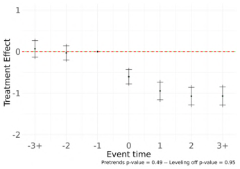

NOTE: figure/graphic rendered as an image from the PDF; its content is not machine-readable text. Caption (if any) follows as the next block.

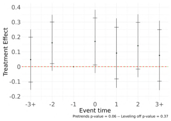

NOTE: figure/graphic rendered as an image from the PDF; its content is not machine-readable text. Caption (if any) follows as the next block.

(a) Gambling Content

(b) LootBox Games

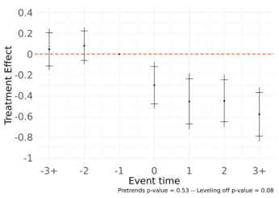

NOTE: figure/graphic rendered as an image from the PDF; its content is not machine-readable text. Caption (if any) follows as the next block.

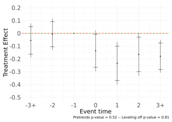

NOTE: figure/graphic rendered as an image from the PDF; its content is not machine-readable text. Caption (if any) follows as the next block.

(c) Total Livestreams

(d) Other Games

#### **7.3 Heterogeneous Treatment Effects**

We now explore whether the policy impact on content creation varies across different types of

streamers, as examining the impact on subgroups of streamers help us better understand the

policy’s effectiveness and investigate the underlying mechanisms.

**HTE on Main Language**. First, we examine potential heterogeneous effect of the banning

Figure 7: Time-Varying Treatment Effects on Content Creation in Group of Unbanned Streamers

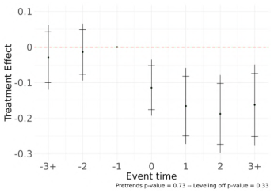

NOTE: figure/graphic rendered as an image from the PDF; its content is not machine-readable text. Caption (if any) follows as the next block.

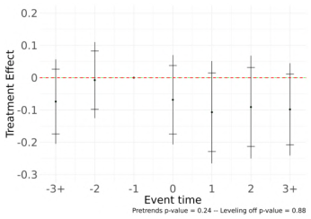

NOTE: figure/graphic rendered as an image from the PDF; its content is not machine-readable text. Caption (if any) follows as the next block.

(a) Gambling Content

(b) LootBox Games

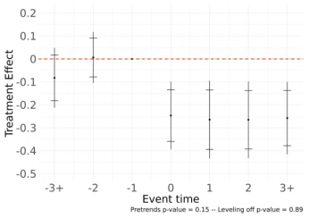

NOTE: figure/graphic rendered as an image from the PDF; its content is not machine-readable text. Caption (if any) follows as the next block.

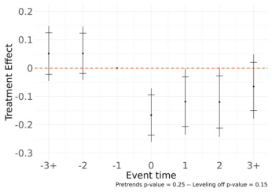

NOTE: figure/graphic rendered as an image from the PDF; its content is not machine-readable text. Caption (if any) follows as the next block.

(c) Total Livestreams

(d) Other Games

policy on streamers of different languages. This might be interesting because the banning

policy only targeted websites that were unlicensed in the U.S, whereas the main language of all

4 websites are English. Moreover, English is not the dominant language in gambling livestreams

on Twitch.<sup>13</sup> Therefore, if the banning policy on English-based websites also decreased gambling

livestreams in other languages, its influence extended beyond its primary target, making it more

effective in controlling risky content across the platform.

Figure 8 shows the treatment effects on gambling livestreams and total livestreams across

the main language groups. We find evidence that although the banning policy only targeted

13Among the 475 gambling streamers in our dataset, 72 used English as the main language, 92 used Spanish, 111 used Portuguese, and 200 used other languages. Streamers tend to use the same language in both gambling and non-gambling streams.

English-based websites, it also had a spillover effect, as the supply of gambling livestreams in

magnitudes. However, the spillover effect on total livestreams is only prominent among banned

streamers, as both Spanish streamers and Portuguese streamers did not decrease their totla

livestreaming hours, compared to untreated streamers in the same language groups.

Figure 8: Heterogeneous Treatment Effects on Streamers with Different Main Languages

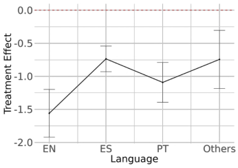

NOTE: figure/graphic rendered as an image from the PDF; its content is not machine-readable text. Caption (if any) follows as the next block.

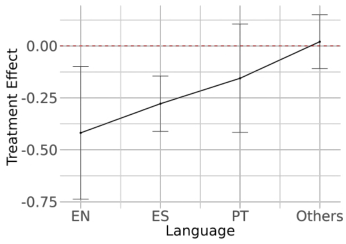

NOTE: figure/graphic rendered as an image from the PDF; its content is not machine-readable text. Caption (if any) follows as the next block.

(a) Gambling, Banned

(b) Gambling, Unbanned

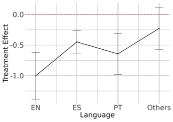

NOTE: figure/graphic rendered as an image from the PDF; its content is not machine-readable text. Caption (if any) follows as the next block.

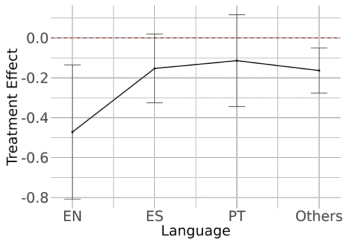

NOTE: figure/graphic rendered as an image from the PDF; its content is not machine-readable text. Caption (if any) follows as the next block.

(c) Total Livestreams, Banned

(d) Total Livestreams, Unbanned

*Notes*. 1. The coefficients in each subfigure show the point estimates of *β*1 for banned streamers and *β*3 for unbanned streamers. 2. The language groups is derived based on the most frequently used language of each streamer, collected at stream-level from Twitch API.

**HTE on Streamer Popularity.** Next, we explore whether the policy impact on content

creation varies across streamers with different levels of popularity. From Figure 9, we find that in

the banned group, streamers with higher popularity reduced their content creation of gambling

livestreams slightly more than streamers with low popularity after the policy. More interestingly,

only streamers with the highest level of popularity in the unbanned group significantly reduced

their content creation of gambling livestreams, with a magnitude of approximately 34.8%. The

policy impact on total livestreaming hours also appears to increase with streamer popularity:

while streamers with low popularity almost did not respond to the policy, streamers with the

highest popularity contributed most to the overall reduction in content creation of total gambling

livestreams. Since streamers with higher popularity had higher average streaming hours on the

platform, our result suggests that the policy led to a tremendous negative impact on the total

content creation across the platform.

Figure 9: Heterogeneous Treatment Effects on Streamers with Different Popularity

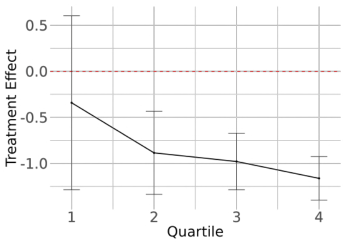

NOTE: figure/graphic rendered as an image from the PDF; its content is not machine-readable text. Caption (if any) follows as the next block.

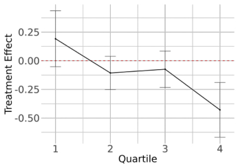

NOTE: figure/graphic rendered as an image from the PDF; its content is not machine-readable text. Caption (if any) follows as the next block.

(a) Gambling, Banned

(b) Gambling, Unbanned

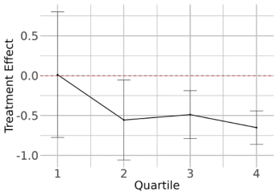

NOTE: figure/graphic rendered as an image from the PDF; its content is not machine-readable text. Caption (if any) follows as the next block.

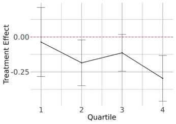

NOTE: figure/graphic rendered as an image from the PDF; its content is not machine-readable text. Caption (if any) follows as the next block.

(c) Total Livestreams, Banned

(d) Total Livestreams, Unbanned

*Notes*. 1. The coefficients in each subfigure show the point estimates of *β*1 for banned streamers and *β*3 for unbanned streamers. 2. The quartiles are derived based on pre-policy average concurrent viewership.

#### **7.4 Mechanism**

Our findings from heterogeneous treatment effects suggest that streamers with higher popular-

ity were affected more by the policy. In this section, we investigate the mechanism behind the

observed heterogeneity, through two potential channels.

**Reputation Concerns**. First, streamers with higher popularity may care more about their

reputation. On one hand, they stand to lose more revenue if prohibited by the platform due to

their high number of subscriptions, in-stream donations and total hours watched. On the other

hand, reducing gambling content and showing support to the platform’s policy can enhance their

reputation within the Twitch community. These factors may incentivize popular streamers to

behave conservatively, resulting in a greater reduction of gambling streams in response to the

policy.

If streamers value their reputation, they are more likely to carefully plan their streaming

content to avoid temporary prohibitions from the platform. We test this hypothesis by running

a DiD specification that includes interactions between treatment indicators and the number of

account prohibitions each streamer received before the policy implementation. Column 1 and

2 in Table 7 present our estimation results. In addition to the negative policy impact on gam-

bling streams, we find that both banned and unbanned streamers reduced gambling livestreams

less if they cared less about their reputation (reflected as having more prohibitions before the

policy implementation). Specifically, a banned streamer with no prior account prohibitions

reduced gambling streams by 64.6%, and each additional prior prohibition resulted in a 2.8%

on top of a baseline decrease of -13.1%. We observe similar effects when we replace the num-

ber of times prohibited by the total number of days prohibited before the policy implementation.

Table 7: Underlying Mechanisms of Policy Impact on Gambling Streams

|  | × Banned Counts |  | × Share of Gambling Streams |
| --- | --- | --- | --- |
|  | Main Effect | Interaction Effect | Main Effect Interaction Effect |
| Banned (β 1) | 1 038*** - . (0 010) . | 0 028*** . (0 007) . | 1 305*** 1 610*** - . . (0 010) (0 020) . . |
| Unbanned (β 3) | 0 141*** - . (0 007) . | 0 060*** . (0 007) . | 0 394*** 1 200*** - . . (0 007) (0 014) . . |
| Streamer FE | ✓ | ✓ | ✓ ✓ |
| Week FE | ✓ | ✓ | ✓ ✓ |
| Observations | 112 222 , | 112 222 , | 112 222 112 222 , , |
| Mean dependent variable | 1 131 . | 1 131 . | 1 131 1 131 . . |

NOTE: table converted from PDF layout to HTML text; cell boundaries are reconstructed. See PDF if exact alignment matters.

*Notes*. All standard errors are clustered at the streamer level. The mean dependent variable is calculated based on observations of all treated streamers before the policy announcement. FE, fixed effect. Significance level: **p <* 0*.*1; ***p <* 0*.*05;****p <* 0*.*01

**Reliance on Gambling Streams**. Second, streamers with higher popularity may have relied

less on gambling content to generate revenue. As a result, they faced lower risks when they

chose to reduce their gambling livestreams. To test this hypothesis, we run a DiD specification

that includes the interactions between treatment indicators and the share of gambling streams

in total livestreams for each streamer. We find that streamers who relied more on gambling

content reduced their gambling livestreams less, as indicated by the positive interaction effect in

Table 7. Specifically, 1% increase in the share of gambling streams decreased the policy impact

by 1.6% for a banned streamer and by 1.2% for an unbanned streamer. These estimates provide

supportive evidence that the policy had a greater impact on those who relied less on gambling

content, partially explaining the higher effectiveness on popular streamers.

#### **7.5 Sensitivity Analysis**

Although we have used multiple data sources and techniques to detect banned content and

banned streamers, one may still concern that some streamers are not classified into the correct

treated group due to missing data issues or measurement error from the data collection process,

which we cannot control. Since we have chosen a conservative approach to detect banned

streamers, our banned group of streamers can be viewed as a subset of streamers who actually

streamed gambling content. Therefore, we focus on potential misclassification in the unbanned

group, which may result in a potential bias in the estimated effects on unbanned streamers.

To address this concern, we conduct a sensitivity analysis to address potential misclassifica-

tion issues in our casual estimates. The sensitivity parameter in our framework is the fraction of

streamers who actually streamed banned content but were classified into the unbanned group,

i.e.

# *{*streamers who streamed banned content *|* Classified in the unbanned group*}* # *{*streamers who streamed unbanned content *|* Classified in the unbanned group*}*

We use this sensitivity parameter to test our estimation results from for the unbanned

group of streamers. We find that the signs of all the estimated effects are robust as long as the

sensitivity parameter is less than 0.999, i.e. less than half of all streamers in the unbanned group

are misclassified. This condition is satisfied as we have more than half of unbanned streamers

using a main language other than English, where the banned websites are all English-based.

We provide a formal proof of identification with misclassification in the DiD framework and the

validity of the sensitivity parameter in Appendix D.

### **8 Demand-Side Results**

In this section, we present estimation results on key demand-side outcome variables. We first

focus on two sets of demand-side treatment effects: the effect on total hours watched by viewers,

one of the most crucial metrics of channel popularity and viewer engagement, and the effect on

three tiers of subscriptions. Then, we discuss how we use network analysis to address potential

violation of SUTVA assumption in the demand-side analysis.

#### **8.1 Total Content Consumption and Revenue Channels**

Table 8 presents estimated causal effects on total hours watched. The SynthDiD estimator

consequence of 17.6% decrease in total streaming hours. Although not completely comparable,

the differences in magnitudes between demand- and supply-side estimates indicate that stream-

ers suffered non-uniformly more in content consumption compared to their reduction in content

creation, suggesting that their viewers before the policy implementation had higher preferences

over gambling content.

Table 8: The Impact of Twitch’s Ban Policy on Total Hours Watched

|  | log(Hours Watched + 1) |  |
| --- | --- | --- |
|  | TWFE | SynthDiD ATTGT |
| Banned (β 1) | 1 694*** - . (0 268) . | 1 696*** 1 529*** - . - . (0 241) (0 317) . . |
| ∆% | 81 6% - . | 81 6% 78 3% - . - . |
| Unbanned (β 3) | 0 523*** - . (0 134) . | 0 554*** 0 659*** - . - . (0 122) (0 155) . . |
| ∆% | 40 7% - . | 42 5% 48 3% - . - . |
| Streamer FE | ✓ | ✓ ✓ |
| Week FE | ✓ | ✓ ✓ |
| Observations | 112 222 , | 112 222 112 222 , , |
| Mean dependent variable | 8 487 . | 8 487 8 487 . . |

NOTE: table converted from PDF layout to HTML text; cell boundaries are reconstructed. See PDF if exact alignment matters.

*Notes*. All standard errors are clustered at the streamer level. The mean dependent variable is calculated based on observations of all streamers before the policy announcement. FE, fixed effect. Significance level: **p <* 0*.*1; ***p <* 0*.*05;****p <* 0*.*01

While total hours watched reflects viewer engagement and content popularity, it does not

directly indicate the revenue received by each streamer. Therefore, we also examine the policy

impact on three tiers of subscriptions on Twitch. These outcome variables are informative for

two reasons: first, the three tiers of subscriptions directly reflect changes in streamers’ total

revenue, as a Tier 1 subscription is worth $4.99, Tier 2 is worth $9.99 and Tier 3 is worth

$24.99. Second, these subscriptions generally do not include exclusive livestreaming content<sup>14</sup>.

Therefore, a higher-tier subscription can be seen as a signal of viewer loyalty and engagement

in the streamer’s community.

For clarity, we only show SynthDiD estimates for these outcome variables in Table 9, where

we present full estimation results in Appendix C. We find that only Tier 1 subscriptions were

significantly affected by the banning policy, with banned streamers experiencing a 44.2% loss

in weekly Tier 1 subscriptions after the policy and unbanned streamers experiencing a loss

of -16.9%, suggesting a huge loss in total revenue for the treated streamers due to the high

number of Tier 1 subscriptions on average. In contrast, we find insignificant estimates of policy

impact on both Tier 2 and Tier 3 subscriptions. Since viewers pay much more for higher

tiers of subscriptions, only a small amount of loyal viewers are willing to support the streamer

at these levels. This finding suggests that, on average, it was unlikely that either banned or

unbanned streamers suffered significant losses in their loyal viewers or engagement from their

core communities.

#### **8.2 Using Network Analysis to Address Potential Violation of SUTVA**

A key assumption to identify the ATT is that the post-policy outcome of each streamer only

depends on her own treatment assignment, commonly referred to as the SUTVA assumption

(Rubin, 1980, 1990). In our context, if viewers focus more on certain types of content instead

of particular streamers, the banning policy might induce viewers to switch to other streamers

who provided the content of their interests. In that sense, the policy restricting the banned

treated group from streaming unlicensed gambling content and thus their viewers for watching

that content may also affect the remaining viewers, suggesting potential spillover between the

demands across streamers both within and between treated and untreated groups.

To mitigate potential violations of SUTVA, we use network analysis on chat logs to eval-

uate the extent of overlapping viewership between streamers. Using this network, we employ

14Viewers who purchase higher-tier subscriptions to a streamer enjoy benefits such as access to additional in-chat emotes, tenure-based chat badges, and subscriber-only chats.

Table 9: The Impact of Twitch’s Ban Policy on Different Tiers of Subscriptions

|  | Tier 1 | Tier 2 | Tier 3 |
| --- | --- | --- | --- |
| Banned (β 1) | 0 584*** - . (0 110) . | 0 017 . (0 011) . | 0 024 - . (0 014) . |
| ∆% | 44 2% - . | - | - |
| Unbanned (β 3) | 0 185** - . (0 054) . | 0 013 . (0 009) . | 0 011 . (0 011) . |
| ∆% | 16 9% - . | - | - |
| Streamer FE | ✓ | ✓ | ✓ |
| Week FE | ✓ | ✓ | ✓ |
| Observations | 112 222 , | 112 222 , | 112 222 , |
| Mean dependent Variable | 3 373 . | 0 406 . | 0 410 . |

NOTE: table converted from PDF layout to HTML text; cell boundaries are reconstructed. See PDF if exact alignment matters.

*Notes*. All standard errors are clustered at the streamer level. The mean dependent variable is calculated based on observations of all streamers before the policy announcement. FE, fixed effect. Significance level: **p <* 0*.*1; ***p <* 0*.*05;****p <* 0*.*01

*Louvain Community Detection*, a community detection algorithm, to identify distinct clusters,

where streamers within the same cluster cluster share many viewers, and streamers across dif-

ferent clusters have minimal or no shared viewers. Finally, we use the *Breadth First Search*

*(BFS) algorithm*, a graph traversing algorithm, to automate the selection of subsets of stream-

ers within a cluster, and to construct treated and untreated groups for valid identification. We

detail each procedure below.

**Network Construction**. We use the list of registered viewers in chats (a subset of the total

viewers of a stream), prior to policy implementation, to construct a network of shared viewer-

ship among streamers.<sup>15</sup> To reduce the dimensionality of the network (which scales up with the

number of streamers), we construct the network using all streamers from the two treated groups

and a random sample of 800 streamers from the untreated group (out of 4626 untreated stream-

ers). After excluding a few streamers with missing chats data, our final network consisting of

1270 streamers (155 banned, 315 unbanned, 800 untreated) with 805,815 edges.

In our network, a *node* represents a streamer, and an *edge* between two nodes indicates the

presence of common viewers between the two streamers. The size of a node is proportional to

the number of unique viewers of a streamer before the policy implementation, and the weight

15Since Twitch does not provide data on the full list of viewers within a stream, we use registered viewers in chats as a proxy for a streamer’s total viewers in stream. The validity of this approach is discussed in Appendix A.

of an edge corresponds to the number of common viewers shared between two streamers. Table

10 shows the summary statistics of viewer counts of the streamers from the three groups.

Table 10: Viewer Count Before the Policy Implementation

| Group | Mean | Std | 5 quantile | 25 quantile | 50 quantile | 75 quantile | 95 quantile |
| --- | --- | --- | --- | --- | --- | --- | --- |
| Untreated | 15394995 , . | 29541497 , . | 13386 , . | 39570 , . | 79335 , . | 1624875 , . | 4919795 , . |
| Unbanned | 18184537 , . | 43827043 , . | 6661 . | 37925 , . | 86980 , . | 1921350 , . | 5244320 , . |
| Banned | 37134568 , . | 54788896 , . | 37822 , . | 108250 , . | 226370 , . | 3579650 , . | 12430920 , . |

NOTE: table converted from PDF layout to HTML text; cell boundaries are reconstructed. See PDF if exact alignment matters.

*Notes*: This table presents the descriptive statistics of viewer counts for different groups of streamers before the policy implementation.

To identify streamers with significant viewer overlaps and enhance visibility and inter-

pretability of the network , we filter out edges with fewer than 1,000 shared viewers. The

threshold is selected heuristically based on the observed 5th quantile of unique viewers with a

group, as shown in Table 10. The interactive version of our network can be accessed at inter-

active network.

**Community Detection**. To construct valid treated and untreated groups where streamers

have minimal or no shared viewers, we use the *Louvain Community Detection* algorithm to

identify distinct clusters within the network, whereas streamers in different clusters are not

densely connected in terms of viewers.<sup>16</sup> Using the algorithm, we identify 52 community clusters

from the network. Table E.0.1 in Appendix E shows the share of streamers with different

treatment status (banned, unbanned, untreated) within each community cluster. Figure 10

shows an illustration of a cluster for each group.

To construct valid treated and untreated groups, we need to ensure that streamers with

different treatment status are separated into distinct clusters, minimizing viewer overlap across

groups. However, from Table E.0.1 and Figure 10, we observe that while it is straightforward

to select clusters for the untreated group (many small clusters consist entirely of untreated

streamers and are well separated from other groups), it is more challenging to select clusters

for the banned and unbanned groups. Most clusters that contain many banned and unbanned

streamers also contain streamers of other treatment status. For example, the cluster with

predominantly unbanned streamers centered around “zloyn” (bottom left in Figure 10) also

contains a large fraction of banned and untreated streamers.

16The Louvain algorithm identifies clusters with high internal connectivity, by recursively merging communities into single nodes and then evaluating how much more densely connected the nodes within a community are, compared to how connected they would be in a random network. We also experimented the Girvan-Newman algorithm for community detection, but found Louvain to be more effective in unfolding communities for large networks.

To address the challenge of mixed-type clusters where most banned and unbanned stream-

ers belong to, we first select a few mixed clusters where it is easy to disentangle streamers of

the same status from others within the same cluster (see Table 11 of the selected clusters).

Then, for each of these selected (but mixed) clusters, we identify the streamer with the most

edges to other streamers of the same treatment status within a cluster (column 2). This central

streamer becomes the focal point of the cluster. We then use the *Breadth-First Search (BFS)*

*algorithm* to traverse the network and systematically remove the neighborhood of streamers

of different status connected to the central streamer (column 6 shows the remained streamers

within a cluster after this step). This approach allows us to automate the selection of subsets of

streamers within a cluster, ensuring that the selected streamers do not have intense connections

with streamers of other types within the same cluster. We detail our automated procedure next.

Table 11: Community Clusters By Treatment Status

|  | Panel A: Communities for Banned Group |  |
| --- | --- | --- |
| Community ID | Center Community Size Streamers Kept | Banned Share (%) |
| 15 | jonvlogs 77 38 | 4935 . |
| 20 | aker 42 11 | 2619 . |
| Others (1 cluster) | 2 2 - | 10000 . |

NOTE: table converted from PDF layout to HTML text; cell boundaries are reconstructed. See PDF if exact alignment matters.

|  | Panel B: Communities for Unbanned Group |  |  |  |
| --- | --- | --- | --- | --- |
| Community ID | Center Community Size |  | Streamers Kept Unbanned Share (%) |  |
| 19 | zloyn | 115 | 82 | 6435 . |
| Others (4 clusters) | - | 9 | 9 | 10000 . |
|  | Panel C: Communities for Untreated Group |  |  |  |
| Community ID | Center | Community Size Streamers Kept |  | Untreated Share (%) |
| 3 | nyanners | 209 | 98 | 7512 . |
| Others (29 clusters) | - | 183 | 183 | 10000 . |

NOTE: table converted from PDF layout to HTML text; cell boundaries are reconstructed. See PDF if exact alignment matters.

*Notes*: This table presents the communities clusters used for each group. Panel A shows clusters used for banned streamers, Panel B shows clusters used for unbanend streamers, and Panel C shows clusters used for untreated streamers. The “others” communities in the column are communities that contain only a treatment status of only one type. Specifically, communities 1, 11,12,13, 16, 18, 21, 22, 23, 24, 26, 28, 30, 32, 34, 35, 36, 37, 38, 39, 40, 41, 42, 43, 44, 45, 46, 47, 49 are solely of untreated streamers; 2,4,7, 51 are solely unbanned streamers; 31 is solely banned streamers.

**BFS-Based Filtering Algorithm**. We leverage Breadth-First Search (BFS), a graph travers-

ing algorithm, to identify a subset of streamers who belong to the same treatment status within

Figure 10: Network of Streamers Based on Common Viewers

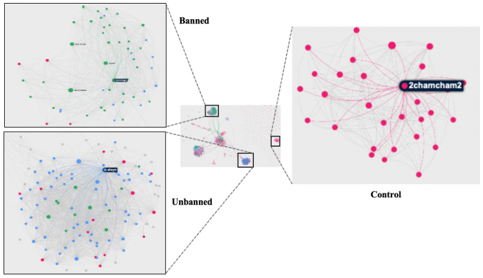

NOTE: figure/graphic rendered as an image from the PDF; its content is not machine-readable text. Caption (if any) follows as the next block.

*Notes.* This figure shows the network of streamers based on common viewers they share, before the policy implementation. The central panel shows the overall streamer network. A node denotes a streamer, and an edge indicates the presence of common viewers between two streamers. The size of a node is the number of viewers of a streamer, and the weight of an edge corresponds to the number of common viewers shared two streamers. The displayed network filters out edge weight that are below 1000 for visibility and identification of clusters. The nodes are colored such that red denotes the untreated group, blue denotes the unbanned (treated) group, and green denotes the banned (treated) group. The zoomed-in sections highlight specific clusters of the network which are predominantly banned (top left), unbanned (bottom left), and untreated (right) groups. The zoomed-in areas provide a clearer view of the connections and streamers’ treatment status within the clusters.

a cluster. The approach allows us to automate the selection process to include enough streamers

of the same status, while effectively handling large complex networks consisting of clusters of

mixed streamer status. We use this process to construct treated and untreated groups for valid

identification, when treated streamers belong to clusters of mixed treatment status.

We illustrate the idea of this process in Figure 11. In **Step 1**, we begin with a central

streamer within a cluster (for example, “jonvlogs” from community 15) and search the network

outward from him, reaching to his closest streamers (Panel (a)). We declare his direct neighbors

to be at distance 1, and exclude his direct streamers who have a different treatment status from

him (Panel (b)). In **Step 2**, we find all neighbors of “jonvlogs”’s direct streamers (not counting

streamers who are already direct neighbors of the central streamer) and declare those to be

at distance 2. For example, “pluzinho” (green node) is one such streamer at distance 1 who

are connected to other streamers of different status (blue node) in Panel (c). The BFS process

then includes all direct neighbors of “pluzinho”, again filtering out any streamers of different

treatment status from him (Panel (d)). We continue the process *interactively* through the

layers of the network. In our case, we stop at distance 3, which covers enough streamers within

a cluster, while ensuring that the retained streamers is homogeneous in terms of treatment

status.

Let *G* be a graph with nodes (streamers) and edges. Let *Q* be the queue<sup>17</sup> for BFS traversal,

and *V* be the set of visited streamers, *T* be the set of target nodes that meet the criteria (i.e.

belong to the same treatment status and cluster). Algorithm 1 gives the full description of the

procedure.

17In BFS, the queue is used to keep track of which streamers (nodes) we need to visit next. We add streamers to the queue as we discover them, and we remove them from the queue as we visit and process them.

**Algorithm 1** BFS-Based Filtering

1: Initialize graph G from the data and set the central streamer center streamer

2: Initialize queue Q *←*[center streamer], visited set V *←{}*, and target streamers set T *← {}*

3: Set center treatment *←*G[center streamer][’treatment’] and center community *←* G[center streamer][’community’]

4: **while** Q is not empty **do**

5: streamer *←*Q.pop(0)

6: **if** streamer */∈*V **then**

7: V.add(streamer)

8: **if** G[streamer][’treatment’] == center treatment and G[streamer][’community’] == center community **then**

9: T.add(streamer)

10: **for all** neighbor *∈*G.neighbors(streamer) **do**

11: **if** neighbor */∈*V **then**

12: Q.append(neighbor)

13: **end if**

14: **end for**

15: **end if**

16: **end if**

17: **end while**

18: **return** filtered streamers with homogeneous treatment status

#### **8.3 Demand-Side Results on Selected Groups**

In Table 12, we summarize causal estimates for the same outcome variables as in Table 8 and

9, and compare them with previously reported results. Since we have aggregated streamers

with the same treatment status to avoid within-group spillover, it is infeasible to construct the

synthetic counterfactual in the SynthDiD method, whereas the *did* package reports the error

message that the treated group is too small to perform the doubly-robust estimator. Therefore,

we report estimates from TWFE-DiD regressions.

We find that all effects are qualitatively similar to previously reported estimates, except

that the DiD estimator at the aggregated level indicates a slight increase in Tier 3 subscriptions

for unbanned streamers at the marginal significance. However, this result does not change

our conclusion that neither banned nor unbanned streamers suffered from losses in their core

viewership, where both groups experienced significant loss in revenue from non-loyal viewers.

Although we expect that the DiD estimates on all collected streamers will overestimate the

ATT on the total hours watched, the estimates in Table 12 suggest that previous results indeed

underestimate the negative impact on the affected streamers. One explanation to the results is

that since the selected streamers share much fewer viewers with others on the platform, they

are in general less popular and can be replaced by other streamers easily when they were forced

Figure 11: Filtering Streamers of Different Treatment Status Iteractively Using BFS

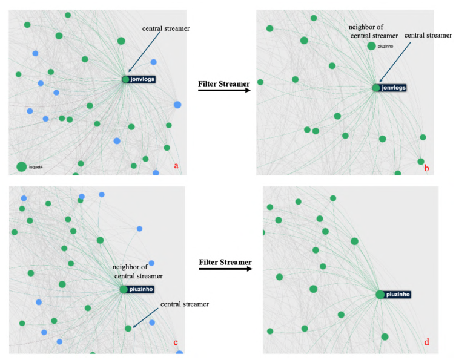

NOTE: figure/graphic rendered as an image from the PDF; its content is not machine-readable text. Caption (if any) follows as the next block.

*Notes.* This figure illustrates the process of filtering streamers within a cluster using the Breadth-First Search (BFS) algorithm. Panel (a) shows the initial cluster with the central streamer “jonvlogs” (green node) and its neighbors, including streamers of different statuses (blue nodes). Panel (b) depicts the cluster after filtering out streamers of different statuses connected to the central streamer. Panel (c) demonstrates the next step of filtering by finding neighbors of the neighbors (e.g., neighbors of one such neighbor “piuzinho”). Panel (d) shows the final filtered cluster with only streamers of the same status connected to the central streamer “piuzinho”. The process continues successively through the network.

not to change their streaming content, resulting in a higher effect on these streamers.

In Table C.0.3 of Appendix C, we present estimation results for the supply-side variables

among the selected groups of streamers. This additional analysis addresses concerns regarding

potential violations of SUTVA on the demand-side outcomes influencing streamers’ decisions

on content production. Overall, the findings corroborate those presented in Section 7. Notably,

the streaming hours for gambling content among unbanned streamers in the selected group

were unaffected by the policy. This outcome is expected as these streamers typically have lower

popularity, making them less responsive to the banning policy, as we displayed in Figure 9.

Table 12: The Impact of Twitch’s Ban Policy on Demand-Side Outcomes, Based on Selected Groups of Streamers

|  | log (Hours Watched + 1) | Tier 1 | Tier 2 | Tier 3 |
| --- | --- | --- | --- | --- |
| Banned | 2 023 (0 259)*** - . . | 0 619 (0 137)*** - . . | 0 018 (0 027) . . | 0 020 (0 023) - . . |
| ∆% | 86 8% - . | 46 1% - . | - | - |
| Unbanned | 0 802 (0 259)** - . . | 0 256 (0 137)* - . . | 0 025 (0 027) . . | 0 045 (0 023)* . . |
| ∆% | 55 2% - . | 22 6% - . | - | 4 6% . |
| Streamer FE | ✓ | ✓ | ✓ | ✓ |
| Week FE | ✓ | ✓ | ✓ | ✓ |
| Observations | 8 694 , | 8 694 , | 8 694 , | 8 694 , |

NOTE: table converted from PDF layout to HTML text; cell boundaries are reconstructed. See PDF if exact alignment matters.

*Notes*. All standard errors are clustered at the streamer level. FE, fixed effect. Significance level: **p <* 0*.*1; ***p <* 0*.*05;****p <* 0*.*01

### **9 Website Traffic Analysis**

To examine whether Twitch’s policy also has an effect on traffic to online gambling websites, we

identify and extract a list of 3,753 websites from text detected via OCR on sampled video frames.

Specifically, these websites are identified by matching patterns using regular expressions (regex)

that start with optional protocols (“http://” or “https://”) and include top-level domains,

which could be either generic (e.g., “.com”,“.net”) or country-specific (e.g., “.us”,“.uk”). We

then manually checked through the website list to refine it down to a subset of 105 websites of

online gambling or gambling-alike content. We define a site as an “online gambling site”, if it

directly offers any online slots, roulette or dice games, whereas users can register and play with

real money. These websites can be broadly categorized into 5 different groups:

Table 13: Gambling Websites Used for Event Study of Website Traffic

| Type | Example |
| --- | --- |
| Banned websites by the policy | stakecom . |
| Unbanned gambling sites detected by OCR | 1betcom . |
| Unbanned gambling sites not detected by OCR | mcluckcom . |
| Unbanned websites of sports betting | 1xbetcom . |
| Gambling sites with different top-level domains | stakemba . |

NOTE: table converted from PDF layout to HTML text; cell boundaries are reconstructed. See PDF if exact alignment matters.

We obtained SimilarWeb’s website traffic data from *Dewey*, which contains monthly total

traffic on a domain and subdomain level with a breakdown by device type since September 2018.

The dataset includes observations of desktop, mobile and overall visits, as well as average visit

duration. We use the data to examine whether banned gambling websites have experienced

sudden traffic changes due to the policy (see Section 9).

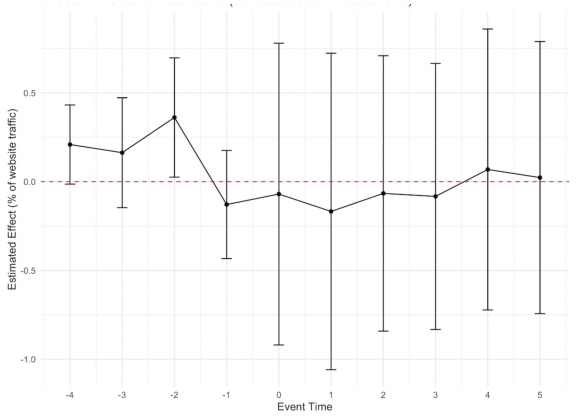

NOTE: figure/graphic rendered as an image from the PDF; its content is not machine-readable text. Caption (if any) follows as the next block.

*Notes.* 1. This figure presents the time-varying treatment effects on the total traffic for banned gambling websites, using unbanned gambling websites described in Table 13 as the control group. 2. We include linear time trends for each website and cluster the standard errors at the website level.

Figure 12 presents the time-varying treatment effect on the total traffic of banned gambling

websites compared to the unbanned gambling websites. The estimate is conducted by including

website and month fixed effects, and allowing for different linear trends per website to untreated

for their differences in life cycle stages. Since the policy reduced promotions of the banned web-

sites on Twitch, it might decrease the total traffic of banned websites and potentially increase

the total traffic of unbanned website streamed on Twitch because they might be exposed rel-

atively more on the livestreaming platform. Therefore, even if the parallel trend assumption

may fail to hold in the analysis, we should still expect a negative estimate if the policy had any

impact on website traffic. However, the persistent null effect in Figure 12 indicates that the

policy did not have any significant impact on traffic to the gambling websites.

### **10 Conclusion**

In this paper, we empirically study the effects of the Twitch’s banning policy on online gambling

livestreams. To do so, we assemble a novel high-frequency panel dataset of livestreams from

top Twitch influencers. We leverage video analysis, text analysis and a threshold-based clas-

sification approach to identify banned versus unbanned gambling content within streams, then

partition streamers into groups which were directly or indirectly affected by the policy. More-

over, we employ multiple empirical approaches to overcome potential identification challenges

in identifying the treatment effects on a variety of supply and demand-side outcome variables.

Our results show that the policy led to a persistent reduction in the supply of gambling

livestreams for streamers reliant on gambling livestreams. However, the policy also reduced

streams of non-gambling content, bringing unwanted side effect on content production to the

platform. Moreover, we find that the policy had more prominent impact on streamers with

higher popularity. We further examine the underlying mechanisms and show that both low

reliance on gambling content and concern over personal reputation could contribute to the non-

uniform effect among streamers. On content consumption, we find that the policy reduced both

total hours watched and low-tier subscriptions for treated streamers. However, the policy did

not reduce high-tier subscriptions, suggesting that these streamers did not suffered from losses

in their core viewership.

Our research is subjected to several limitations. First, it is plausible that streamers who

were significantly affected by the policy might migrate to other platforms to stream gambling

content. However, we do not have access to data from other platforms supporting online gam-

bling streams, such as YouTube or Kick. It would be interesting to examine potential spillover

effects from Twitch to other livestreaming platforms due to the banning policy. Second, due to

the lack of individual-level attributes of viewers and the low information density of chat logs,

it is more difficult to evaluate the policy impact on gambling behavior, expenditures or mental

health issues of viewers of gambling streams. With more information about individual viewers,

studying the policy effect on these outcomes might be a fruitful future research area.

Our findings provide managerial insights for influencers, platform developers and policy-

makers. First, our results can assist streaming platforms in assessing the impact of content

restriction policies and guide them in advising streamers on optimizing their content for in-

creased profitability. Second, our results provide new evidence on the debate on the need for

regulating video games featuring gambling-like content, which helps game developers improve

their product design and evaluate welfare effects. Finally, our findings enable policymakers to

better anticipate the outcomes of implementing restrictive regulations or laws on online gam-

bling, facilitating more effective and informed policymaking in the future.

### **References**

Abadie, A., Diamond, A. and Hainmueller, J. (2010), ‘Synthetic control methods for compar-

ative case studies: Estimating the effect of california’s tobacco control program’, *Journal of*

*the American statistical Association* **105**(490), 493–505.

Abadie, A. and Gardeazabal, J. (2003), ‘The economic costs of conflict: A case study of the

basque country’, *American economic review* **93**(1), 113–132.

Amano, T. and Simonov, A. (2023), ‘A welfare analysis of gambling in video games’, *Available*

*at SSRN 4355019* .

Ananthakrishnan, U. M., Li, B. and Smith, M. D. (2020), ‘A tangled web: Should online review

portals display fraudulent reviews?’, *Information Systems Research* **31**(3), 950–971.

Aridor, G., Jim´enez-Dur´an, R., Levy, R. and Song, L. (2024), ‘The economics of social media’.

Arkhangelsky, D., Athey, S., Hirshberg, D. A., Imbens, G. W. and Wager, S. (2021), ‘Synthetic

difference-in-differences’, *American Economic Review* **111**(12), 4088–4118.

Beck, B. B., Wuyts, S. and Jap, S. (2023), ‘Guardians of trust: How review platforms can fight

fakery and build consumer trust’, *Journal of Marketing Research* p. 00222437231195576.

Beknazar-Yuzbashev, G., Jim´enez Dur´an, R., McCrosky, J. and Stalinski, M. (2022), ‘Toxic

content and user engagement on social media: Evidence from a field experiment’, *Available*

*at SSRN 4307346* .

Berman, R. and Israeli, A. (2022), ‘The value of descriptive analytics: Evidence from online

retailers’, *Marketing Science* **41**(6), 1074–1096.

Breiman, L. (2017), *Classification and regression trees*, Routledge.

Callaway, B. and Sant’Anna, P. H. (2021), ‘Difference-in-differences with multiple time periods’,

*Journal of econometrics* **225**(2), 200–230.

Clarke, D., Paila˜nir, D., Athey, S. and Imbens, G. (2023), ‘Synthetic difference in differences

estimation’, *arXiv preprint arXiv:2301.11859* .

Cusumano, M. A., Gawer, A. and Yoffie, D. B. (2021), ‘Can self-regulation save digital plat-

forms?’, *Industrial and Corporate Change* **30**(5), 1259–1285.

Freyaldenhoven, S., Hansen, C., P´erez, J. P. and Shapiro, J. M. (2021), Visualization, iden-

tification, and estimation in the linear panel event-study design, Technical report, National

Bureau of Economic Research.

GameRant (2022), https://gamerant.com/twitch-gambling-ban-ineffective-too-

little-too-late/?newsletter_popup=1.

Gandhi, A. and Hollenbeck, B. (2023), Misinformation and mistrust: The equilibrium effects of

fake reviews on amazon. com, Technical report, Technical Report, UCLA Anderson School.

Howard, J. W. (2019), ‘Free speech and hate speech’, *Annual Review of Political Science*

**22**(1), 93–109.

Huang, Y. and Morozov, I. (2023), ‘The promotional effects of live streams by twitch influencers’,

*Available at SSRN 4582182* .

Johnson, G., Lin, T., Cooper, J. C. and Zhong, L. (2024), ‘Coppacalypse? the youtube settle-

ment’s impact on kids content’, *Available at SSRN 4430334* .

Kircher, T. and Foerderer, J. (2024), ‘Ban targeted advertising? an empirical investigation of

the consequences for app development’, *Management Science* **70**(2), 1070–1092.

Montiel Olea, J. L. and Plagborg-Møller, M. (2019), ‘Simultaneous confidence bands: Theory,

implementation, and an application to svars’, *Journal of Applied Econometrics* **34**(1), 1–17.

Rubin, D. B. (1980), ‘Randomization analysis of experimental data: The fisher randomization

test comment’, *Journal of the American statistical association* **75**(371), 591–593.

Rubin, D. B. (1990), ‘Comment: Neyman (1923) and causal inference in experiments and

observational studies’, *Statistical Science* **5**(4), 472–480.

StreamHatchet (2022b), https://streamhatchet.com/blog/blog-online-gambling-rises-

on-twitch/.

StreamScheme (2023), https://www.streamscheme.com/twitch-statistics/.

Yang, J. and Simonov, A. (2024), ‘Creator content production decisions on twitch.tv’, *Work in*

*Progress* .

Zhang, W., Liu, Z., Liu, X. and Muller, E. (2023), ‘Doubling revenues by adopting livestream

shopping: A synthetic did approach’, *Available at SSRN 4318978* .

## **Appendix**

### **Table of Contents**

| A | Streamer Data Collection | 48 |
| --- | --- | --- |
| B | Banned Content and Streamer Detection | 49 |
|  | B1 Matching Video Clips to Original Streams . . . . . . . . . . . . . . . . . . . . . . | 49 |
|  | B2 Alternative Detection of Banned Content From Stream Titles . . . . . . . . . . . | 51 |
|  | B3 Ground Truth Sample Justification . . . . . . . . . . . . . . . . . . . . . . . . . . | 51 |
|  | B4 Inference and Prediction Using Chats . . . . . . . . . . . . . . . . . . . . . . . . | 52 |
| C | Additional Estimation Results | 53 |
| D | Technical Details of Sensitivity Analysis on Misclassification | 57 |
|  | D1 Details of the Sensitivity Analysis . . . . . . . . . . . . . . . . . . . . . . . . . . . | 57 |
|  | D2 Robustness of Main Results . . . . . . . . . . . . . . . . . . . . . . . . . . . . . . | 59 |
|  | D3 Proofs for Appendix D . . . . . . . . . . . . . . . . . . . . . . . . . . . . . . . . . | 60 |
| E | Network Analysis | 62 |

NOTE: table converted from PDF layout to HTML text; cell boundaries are reconstructed. See PDF if exact alignment matters.

### **A Streamer Data Collection**

In our main data, we utilized a subset of high-frequency streaming activity data collected by

Yang and Simonov (2024). This data tracks the streaming activities of 30,000 Twitch streamers

(and individual registered viewers in streams), by sending requests to the Twitch API every 15

minutes from October 26th, 2022 to August 20th, 2023. Every 15 minutes, the authors retrieved

from the API the stream information (e.g., started time, streamed game, viewer count, registered

viewer list) of all tracked streamers. Table A.0.1 describes variables retrieved from the API at

the time of each request.

Table A.0.1: Variable definitions

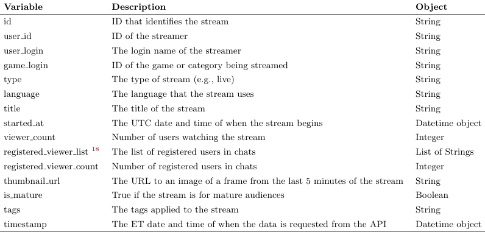

NOTE: complex table shown as an image of the PDF; the text below is a rough machine extraction and may be mis-aligned.

**extracted text (unreliable layout)**

The streamers are pre-selected from a list of 3,606,607 streamers who appear in a 1-month

pilot study (September 21st, 2022 and October 18th, 2022). During the pilot study, the authors

sent requests to the Twitch API, at an hourly rate, to retrieve the top 100,000 most-viewed

streamers that were live on Twitch at the time of the request. In total, the pilot study covers

activities of 3,606,607 unique streamers broadcasting 34,704 types of content (e.g., both games

and non-games such as “Just Chatting”, “Pools, Hot Tubs, and Beaches”, “Sports”). From this

list, the authors then selected a subset of 30,000 streamers to track using weighted sampling,

with weights proportional to the average viewership over the pilot study. The sampling approach

ensures that the tracked streamers are representative of streamers on the Twitch platform (i.e.,

covering both superstars and lesser-known streamers). The sample size was selected by taking

into account: (1) the daily quota for Twitch API requests, (2) the need to balance data collec-

tion efficiency and coverage (since IDs of registered viewers in streams were also tracked).

18Registered viewers in chats were collected from the Twitch TMI API. The data collection on registered viewers stopped on March 31st, 2023, after which Twitch permanently shut down the third-party Legacy Chatters endpoint on April 3, 2023.

viewers, we use registered viewers in chats to proxy for all viewers in a stream. This enables us

to use individuals’ watching history to construct valid treated and untreated groups to study

distribution of registered viewers in chats is generally representative of the total viewership in

stream, evidenced by similar distributions and medians (except that viewer count has a higher

mean, as registered viewers in chats is a subset of viewers in streams) and high correlation

(correlation = 0.988).

Figure A.0.1: Distribution of Registered Viewers vs Viewers

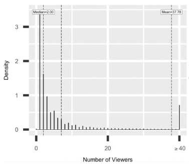

NOTE: figure/graphic rendered as an image from the PDF; its content is not machine-readable text. Caption (if any) follows as the next block.

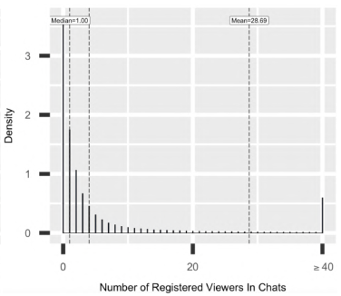

NOTE: figure/graphic rendered as an image from the PDF; its content is not machine-readable text. Caption (if any) follows as the next block.

### **B Banned Content and Streamer Detection**

#### **B.1 Matching Video Clips to Original Streams**

To match video clips to their original streams, we need to know the exact start and end times of

a clip. However, (1) not all clips have a video offset time from the Twitch API, which indicates

how many seconds into a video (and thus stream) the start of the clip occurred, and (2) a clip’s

created time from the Twitch API can sometimes reflect its upload time, but not the time of

when the actual content in the clip was broadcasted. This can be an issue if a lag between the

timestamps is severe.

For clips that have such issues, we employ several strategies to correctly matching them to

their streams. We start by filtering clips with the streamer’s desktop time displayed during

the broadcast (see Figure B.1.1). A streamer’s desktop time represents the actual broadcast

time at his or her local time. OCR can extract these timestamps (usually containing only the

date, hour and minute components of a timestamp, no seconds) as part of the texts. However,

observing streamers’ actual broadcast times from video clips is also not enough for matching,

with the reasons as follows. First, sometimes multiple timestamps (including the streamer’s

desktop time) can be detected by OCR from a video frame. This happens when a video also

displays chats or other information that also come with timestamps. Second, streamers may

operate at different time zones, which can alter both the date and the hour component of

a timestamp. Third, streamers may have their system time displayed in different formats

(e.g., DD/MM/YYYY vs MM/DD/YYYY, or 09:20 PM vs 21:20), which creates confusions in

matching to their streams’ timestamps.

Figure B.1.1: Desktop Time During A Broadcast

[figure not shown]

NOTE: figure/graphic rendered as an image from the PDF; its content is not machine-readable text. Caption (if any) follows as the next block.

We combine several different methods to address above the issues. First, we note that a

streamer’s desktop time always appears in an OCR’s extracted texts as the last timestamp.

This is because almost all gambling streamers use windows systems, where the desktop time is

always displayed in the lower right corner. OCR detects text in reading order, and so regardless

of whether the frame is read from left to right or top to bottom, the timestamp always appears

close to the end of the extracted texts. Next, we check whether a clip’s upload time corresponds

to actual broadcast time as reflected by a streamer’s system time detected by OCR, using the

following 2-step procedure. In **step 1**, we start by matching a streamer’s system time with

the clip’s upload time using only the *minute* component of the two timestamps. We allow a

discrepancy of up to 3 minutes between the two timestamps, considering the maximum duration

of a clip and minor time differences due to the transition of a minute (since desktop time does

not show the seconds component of a timestamp, 9:30 PM can either be the start of 9:30 PM

or close to 9:31PM). Our rationale is that it is highly unlikely for the minute component of the

timestamps to randomly fall within the same 3-minute range. In **step 2**, we verify the *date*

*and hour* components of the two timestamps. Twitch records timestamps in UTC. Given that

there are 24 time zones, any local time can be up to 12 hours (in rare cases, 14 hours) ahead

or behind UTC. We retain only clips where the hour difference of the two timestamps does not

exceed 12 hours and, in addition, the clips fall within a streamer’s local time zone. We use

a combined approach to determine a streamer’s local time zone. First, we obtain information

about a streamer’s country and city of residence from *Streams Charts*. Additionally, we identify

the most common hour difference relative to UTC across all available clips of a streamer and

use it to infer about the time zone the streamer is located. The remaining clips with clear start

and end times are matched to their original streams for analysis.

#### **B.2 Alternative Detection of Banned Content From Stream Titles**

Table B.2.1: Detecting Banned Content From Stream Title

|  | Streamers with Gambling Content | Streamers without Gambling Content |
| --- | --- | --- |
| No Streamers . | 475 | 4626 |
| Panel A: Using banned website referral links |  |  |
| Banned Referrals in Any Stream Titles | 52 | 2 |
| Banned Referrals in Gambling Stream Titles | 50 | 0 |
| Banned Referrals in Any Stream Titles In Post -Treatment Period | 2 | 0 |
| Panel B: Using banned website keywords |  |  |
| Banned Keywords in Any Stream Titles | 90 | 4 |
| Banned Keywords in Gambling Stream Titles | 85 | 0 |
| Banned Keywords in Any Stream Titles In Post -Treatment Period | 4 | 1 |

NOTE: table converted from PDF layout to HTML text; cell boundaries are reconstructed. See PDF if exact alignment matters.

*Notes*: This table shows the detection of banned streamers by various source types for both the treated and untreated groups.

#### **B.3 Ground Truth Sample Justification**

We note that OCR with no banned website keywords detected at all 3 frames is a **necessary**

**but not sufficient condition** to make sure that a clip shows unbanned gambling content.

For example, a clip can have content from an banned website, but OCR cannot detect it if

a clip does not feature banned website logo or keyword in frames. (However, if OCR detects

banned content, it means that a streamer indeed streams banned content.) Thus, we need to use

multiple criteria to generate the ground truth unbanned gambling sample as indicated above.

In addition, we checked the (stream) titles for all gambling clips with no banned website

no referral link in title and the clips are all from streamers with no history of streaming banned

content based on all available clips pre-policy). To enforce an even stricter restriction, when we

generate the ground truth sample, we allow neither banned referral link nor banned keyword to

appear in stream title. The multiple criteria we impose ensure a ground truth banned sample

(even if there is misclassification, we justify that the probability is extremely low).

Table B.3.1: Detecting Banned Content From Stream Title

|  | Video Clips |
| --- | --- |
| Total Number | 475 |
| Misclassified unbanned Title (OCR) | 2 |
| Misclassified unbanned Title (OCR + Streamer History) | 2 |

NOTE: table converted from PDF layout to HTML text; cell boundaries are reconstructed. See PDF if exact alignment matters.

*Notes*: This table shows the detection of banned streamers by various source types for both the treated and untreated groups.

#### **B.4 Inference and Prediction Using Chats**

Table B.4.1 summarizes the in-sample and out-of-sample performance.<sup>19</sup>

(a) Panel A: In-Sample Performance

| Measure | Best Threshold | In-Sample Results Across Folds |
| --- | --- | --- |
| Total Error | 030 . | 0001 . |
| Weighted Total Error | 030 . | 0003 . |
| Accuracy | 030 . | 0976 . |
| AUC | 030 . | 0976 . |
| Precision | 105 . | 0991 . |
| Recall | 000 . | 0978 . |
| F1 -Score | 025 . | 0976 . |

NOTE: table converted from PDF layout to HTML text; cell boundaries are reconstructed. See PDF if exact alignment matters.

(b) Panel B: Out-Of-Sample Performance

[output not shown]

NOTE: table converted from PDF layout to HTML text; cell boundaries are reconstructed. See PDF if exact alignment matters.

[output not shown]

NOTE: table converted from PDF layout to HTML text; cell boundaries are reconstructed. See PDF if exact alignment matters.

Figure B.4.1: Aggregated Confusion Matrix Across Folds

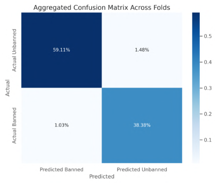

NOTE: figure/graphic rendered as an image from the PDF; its content is not machine-readable text. Caption (if any) follows as the next block.

*Notes.* This figure shows aggregated confusion matrices across folds.

### **C Additional Estimation Results**

In this section, we present full estimation results of supply-side and demand-side outcome

variables.

Table C.0.1: Full Estimation Results of Supply-Side Outcomes

(a) Estimates for Gambling and LootBox Games

[output not shown]

NOTE: table converted from PDF layout to HTML text; cell boundaries are reconstructed. See PDF if exact alignment matters.

(b) Estimates for Streaming Hours and Other Games

[output not shown]

NOTE: table converted from PDF layout to HTML text; cell boundaries are reconstructed. See PDF if exact alignment matters.

Table C.0.2: Full Estimation Results of Demand-Side Outcomes

(a) Estimates for Hours Watched and Tier 1 Subscriptions

[output not shown]

NOTE: table converted from PDF layout to HTML text; cell boundaries are reconstructed. See PDF if exact alignment matters.

[output not shown]

NOTE: table converted from PDF layout to HTML text; cell boundaries are reconstructed. See PDF if exact alignment matters.

Table C.0.3: Full Estimation Results of Isolated Streamers

(a) Supply-Side Outcomes

[output not shown]

NOTE: table converted from PDF layout to HTML text; cell boundaries are reconstructed. See PDF if exact alignment matters.

(b) Demand-Side Outcomes

[output not shown]

NOTE: table converted from PDF layout to HTML text; cell boundaries are reconstructed. See PDF if exact alignment matters.

### **D Technical Details of Sensitivity Analysis on Misclassification**

#### **D.1 Details of the Sensitivity Analysis**

To show the validity of our sensitivity analysis, we first summarize our problem with a more

general econometric framework. Denote the outcome variable as *Yt*(*D<sup>∗</sup>*

**equation / math rendering (image)**

NOTE: contains mathematical notation; text above is the PDF text layer and symbols may be mis-extracted. Image shows the original.

denotes the pre- and post-treatment period respectively<sup>20</sup>, and *D<sup>∗</sup>*

1<sup>,</sup> *<sup>D</sup><sup>∗</sup>* 2 <sup>denote the binary treat-</sup>

ments (“banned” group and “unbanned” group) received by each streamer. However, *D<sup>∗</sup>*

1 <sup>and</sup>

**equation / math rendering (image)**

NOTE: contains mathematical notation; text above is the PDF text layer and symbols may be mis-extracted. Image shows the original.

treatment assignment *D*1*, D*2 from data, where *D*1*, D*2 may not be identical to *D<sup>∗</sup>*

1*<sup>, D</sup><sup>∗</sup>* 2 <sup>for</sup> <sup>all</sup>

**equation / math rendering (image)**

NOTE: contains mathematical notation; text above is the PDF text layer and symbols may be mis-extracted. Image shows the original.

streamers. For example, if a streamer indeed received the first treatment, i.e. she should have

been classified into the “banned” group, but were misclassified into the “unbanned” group in

our dataset because we found no evidence of streaming banned content, then *D<sup>∗</sup>*

1 <sup>=</sup>*<sup>D</sup>*<sup>2</sup> <sup>= 1</sup> <sup>and</sup>

*D*1 = *D<sup>∗</sup>*

**equation / math rendering (image)**

NOTE: contains mathematical notation; text above is the PDF text layer and symbols may be mis-extracted. Image shows the original.

Using the above notations, we can rewrite our outcomes variable as follows:

*Yt* =

**equation / math rendering (image)**

NOTE: contains mathematical notation; text above is the PDF text layer and symbols may be mis-extracted. Image shows the original.

**equation / math rendering (image)**

NOTE: contains mathematical notation; text above is the PDF text layer and symbols may be mis-extracted. Image shows the original.

**equation / math rendering (image)**

NOTE: contains mathematical notation; text above is the PDF text layer and symbols may be mis-extracted. Image shows the original.

*Yt*(1*,* 0)*D<sup>∗</sup>*

**equation / math rendering (image)**

NOTE: contains mathematical notation; text above is the PDF text layer and symbols may be mis-extracted. Image shows the original.

**equation / math rendering (image)**

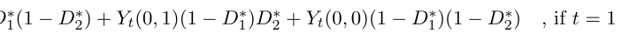

NOTE: contains mathematical notation; text above is the PDF text layer and symbols may be mis-extracted. Image shows the original.

*Yt*(0*,* 0) , if *t* = 0

(9)

In this framework, (*Y*0*, Y*1*, D*1*, D*2) are *observed* from the dataset, whereas (*D<sup>∗</sup>*

1*<sup>, D</sup><sup>∗</sup>* 2<sup>)</sup> <sup>are</sup> <sup>latent</sup>

variables. We do not impose any latent structures on how the true treatment assignments are

mapped to observed treatment assignments. Instead, we impose identification restrictions and

bounds on conditional probabilities of (mis)classifications in this framework.

As in all other DiD frameworks, the identification of ATT relies on imposing the parallel

trend assumption. However, we require extra parallel trends because of potential misclassifica-

tion. We state our assumptions need for identication as follows:

**Assumption 1 (Parallel Trends)** *.*

**equation / math rendering (image)**

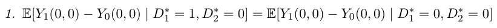

NOTE: contains mathematical notation; text above is the PDF text layer and symbols may be mis-extracted. Image shows the original.

*2.* E[*Y*1(0*,* 0) *−Y*0(0*,* 0) *| D<sup>∗</sup>* 1 <sup>= 1</sup>*<sup>, D</sup><sup>∗</sup>* 2 <sup>= 0</sup>*<sup>, D</sup>*<sup>1</sup> <sup>= 1</sup>*<sup>, D</sup>*<sup>2</sup> <sup>= 0] =</sup>

**equation / math rendering (image)**

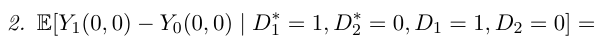

NOTE: contains mathematical notation; text above is the PDF text layer and symbols may be mis-extracted. Image shows the original.

E[*Y*1(0*,* 0) *−Y*0(0*,* 0) *| D<sup>∗</sup>*

**equation / math rendering (image)**

NOTE: contains mathematical notation; text above is the PDF text layer and symbols may be mis-extracted. Image shows the original.

1 <sup>= 1</sup>*<sup>, D</sup><sup>∗</sup>* 2 <sup>= 0</sup>*<sup>, D</sup>*<sup>1</sup> <sup>= 0</sup>*<sup>, D</sup>*<sup>2</sup> <sup>= 1]</sup>*<sup>,</sup>*

**equation / math rendering (image)**

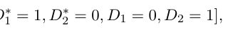

NOTE: contains mathematical notation; text above is the PDF text layer and symbols may be mis-extracted. Image shows the original.

E[*Y*1(0*,* 0) *−Y*0(0*,* 0) *| D<sup>∗</sup>*

**equation / math rendering (image)**

NOTE: contains mathematical notation; text above is the PDF text layer and symbols may be mis-extracted. Image shows the original.

1 <sup>= 0</sup>*<sup>, D</sup><sup>∗</sup>* 2 <sup>= 1</sup>*<sup>, D</sup>*<sup>1</sup> <sup>= 1</sup>*<sup>, D</sup>*<sup>2</sup> <sup>= 0] =</sup>

**equation / math rendering (image)**

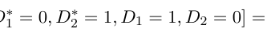

NOTE: contains mathematical notation; text above is the PDF text layer and symbols may be mis-extracted. Image shows the original.

E[*Y*1(0*,* 0) *−Y*0(0*,* 0) *| D<sup>∗</sup>*

**equation / math rendering (image)**

NOTE: contains mathematical notation; text above is the PDF text layer and symbols may be mis-extracted. Image shows the original.

1 <sup>= 0</sup>*<sup>, D</sup><sup>∗</sup>* 2 <sup>= 1</sup>*<sup>, D</sup>*<sup>1</sup> <sup>= 0</sup>*<sup>, D</sup>*<sup>2</sup> <sup>= 1]</sup>*<sup>.</sup>*

**equation / math rendering (image)**

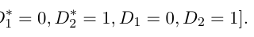

NOTE: contains mathematical notation; text above is the PDF text layer and symbols may be mis-extracted. Image shows the original.

The first part of Assumption 1 is identical to the parallel trend assumption in standard

DiD frameworks without misclassification. In addition, the second part of Assumption 1 posits

that the outcome variables of both the correctly classified streamers and misclassified streamers

should follow the same trend within each group on the same true treatment assignments *D<sup>∗</sup>*

1*<sup>, D</sup><sup>∗</sup>* 2<sup>,</sup>

**equation / math rendering (image)**

NOTE: contains mathematical notation; text above is the PDF text layer and symbols may be mis-extracted. Image shows the original.

20For simplicity, we present all identification results based on a two-period setup. All results can be extended directly into a panel model with multiple pre- and post-treatment periods.

i.e. the expected outcome is mean independent of the treatment arm within each (true) treated

group.

To show the relationship between our DiD estimates and the causal estimands of interest,

we first state the following result which decomposes the DiD estimator under our setup:

#### **Proposition 1**

*β*1 = E[*Y*1(1*,* 0) *−Y*1(0*,* 0) *| D<sup>∗</sup>*

**equation / math rendering (image)**

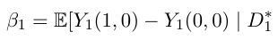

NOTE: contains mathematical notation; text above is the PDF text layer and symbols may be mis-extracted. Image shows the original.

**equation / math rendering (image)**

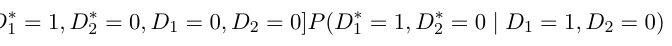

NOTE: contains mathematical notation; text above is the PDF text layer and symbols may be mis-extracted. Image shows the original.

+ E[*Y*1(0*,* 1) *−Y*1(0*,* 0) *| D<sup>∗</sup>*

**equation / math rendering (image)**

NOTE: contains mathematical notation; text above is the PDF text layer and symbols may be mis-extracted. Image shows the original.

1 <sup>= 0</sup>*<sup>, D</sup><sup>∗</sup>* 2 <sup>= 1</sup>*<sup>, D</sup>*<sup>1</sup> <sup>= 1</sup>*<sup>, D</sup>*<sup>2</sup> <sup>= 0]</sup>*<sup>P</sup>*<sup>(</sup>*<sup>D</sup><sup>∗</sup>* 1 <sup>= 0</sup>*<sup>, D</sup><sup>∗</sup>* 2 <sup>= 1</sup>*<sup>|</sup><sup>D</sup>*<sup>1</sup> <sup>= 1</sup>*<sup>, D</sup>*<sup>2</sup> <sup>= 0)</sup>

**equation / math rendering (image)**

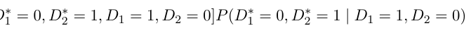

NOTE: contains mathematical notation; text above is the PDF text layer and symbols may be mis-extracted. Image shows the original.

*−*E[*Y*1(1*,* 0) *−Y*1(0*,* 0) *| D<sup>∗</sup>*

**equation / math rendering (image)**

NOTE: contains mathematical notation; text above is the PDF text layer and symbols may be mis-extracted. Image shows the original.

1 <sup>= 1</sup>*<sup>, D</sup><sup>∗</sup>* 2 <sup>= 0</sup>*<sup>, D</sup>*<sup>1</sup> <sup>= 0</sup>*<sup>, D</sup>*<sup>2</sup> <sup>= 0]</sup>*<sup>P</sup>*<sup>(</sup>*<sup>D</sup><sup>∗</sup>* 1 <sup>= 1</sup>*<sup>, D</sup><sup>∗</sup>* 2 <sup>= 0</sup>*<sup>|</sup><sup>D</sup>*<sup>1</sup> <sup>= 0</sup>*<sup>, D</sup>*<sup>2</sup> <sup>= 0)</sup>

**equation / math rendering (image)**

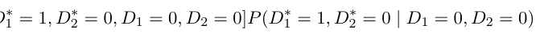

NOTE: contains mathematical notation; text above is the PDF text layer and symbols may be mis-extracted. Image shows the original.

*−*E[*Y*1(0*,* 1) *−Y*1(0*,* 0) *| D<sup>∗</sup>*

**equation / math rendering (image)**

NOTE: contains mathematical notation; text above is the PDF text layer and symbols may be mis-extracted. Image shows the original.

1 <sup>= 0</sup>*<sup>, D</sup><sup>∗</sup>* 2 <sup>= 1</sup>*<sup>, D</sup>*<sup>1</sup> <sup>= 0</sup>*<sup>, D</sup>*<sup>2</sup> <sup>= 0]</sup>*<sup>P</sup>*<sup>(</sup>*<sup>D</sup><sup>∗</sup>* 1 <sup>= 0</sup>*<sup>, D</sup><sup>∗</sup>* 2 <sup>= 1</sup>*<sup>|</sup><sup>D</sup>*<sup>1</sup> <sup>= 0</sup>*<sup>, D</sup>*<sup>2</sup> <sup>= 0)</sup>

**equation / math rendering (image)**

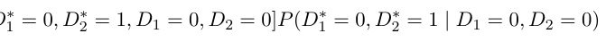

NOTE: contains mathematical notation; text above is the PDF text layer and symbols may be mis-extracted. Image shows the original.

*and β*3 *can be decomposed similarly.*

way. Therefore, we can rule out several possibilities of misclassification in our dataset. First,

we have no misclassified streamers in the untreated group, as our untreated group only contains

streamers with no record of streaming any gambling content in the ground-truth data extracted

from Twitch API. Second, we have no misclassified streamers in the observed banned group.

This is because all streamers in this group had shown sufficient evidence of streaming banned

content. We summarize these restrictions as the following condition:

#### **Condition 1 (Conditional Probabilities of Classifications)**

*P*(*D<sup>∗</sup>*

**equation / math rendering (image)**

NOTE: contains mathematical notation; text above is the PDF text layer and symbols may be mis-extracted. Image shows the original.

1 <sup>= 1</sup>*<sup>, D</sup><sup>∗</sup>* 2 <sup>= 0</sup>*<sup>|</sup><sup>D</sup>*<sup>1</sup> <sup>= 0</sup>*<sup>, D</sup>*<sup>2</sup> <sup>= 0) = 0</sup>

**equation / math rendering (image)**

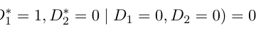

NOTE: contains mathematical notation; text above is the PDF text layer and symbols may be mis-extracted. Image shows the original.

*P*(*D<sup>∗</sup>*

**equation / math rendering (image)**

NOTE: contains mathematical notation; text above is the PDF text layer and symbols may be mis-extracted. Image shows the original.

1 <sup>= 0</sup>*<sup>, D</sup><sup>∗</sup>* 2 <sup>= 1</sup>*<sup>|</sup><sup>D</sup>*<sup>1</sup> <sup>= 0</sup>*<sup>, D</sup>*<sup>2</sup> <sup>= 0) = 0</sup>

**equation / math rendering (image)**

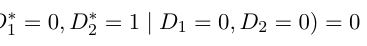

NOTE: contains mathematical notation; text above is the PDF text layer and symbols may be mis-extracted. Image shows the original.

*P*(*D<sup>∗</sup>*

**equation / math rendering (image)**

NOTE: contains mathematical notation; text above is the PDF text layer and symbols may be mis-extracted. Image shows the original.

1 <sup>= 1</sup>*<sup>, D</sup><sup>∗</sup>* 2 <sup>= 0</sup>*<sup>|</sup><sup>D</sup>*<sup>1</sup> <sup>= 1</sup>*<sup>, D</sup>*<sup>2</sup> <sup>= 0) = 1</sup>

**equation / math rendering (image)**

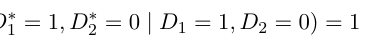

NOTE: contains mathematical notation; text above is the PDF text layer and symbols may be mis-extracted. Image shows the original.

0 *≤P*(*D<sup>∗</sup>* 1 <sup>= 1</sup>*<sup>, D</sup><sup>∗</sup>* 2 <sup>= 0</sup>*<sup>|</sup><sup>D</sup>*<sup>1</sup> <sup>= 0</sup>*<sup>, D</sup>*<sup>2</sup> <sup>= 1)</sup>*<sup>≤</sup>*<sup>1</sup>

**equation / math rendering (image)**

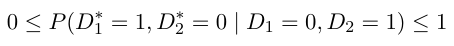

NOTE: contains mathematical notation; text above is the PDF text layer and symbols may be mis-extracted. Image shows the original.

Based on these conditions, we can prove that we have correctly identified ATT for the

banned streamers, and our causal estimate of the unbanned streamers can be decomposed into

a weighted average of the actual ATT for the two treated groups. We summarize these results

in the following proposition:

**Proposition 2** *Suppose that Assumption 1 and Condition 1 hold. Then,*

*β*1 =E[*Y*1(1*,* 0) *−Y*1(0*,* 0) *| D<sup>∗</sup>*

**equation / math rendering (image)**

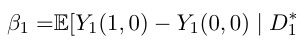

NOTE: contains mathematical notation; text above is the PDF text layer and symbols may be mis-extracted. Image shows the original.

1 <sup>= 1</sup>*<sup>, D</sup><sup>∗</sup>* 2 <sup>= 0</sup>*<sup>, D</sup>*<sup>1</sup> <sup>= 1</sup>*<sup>, D</sup>*<sup>2</sup> <sup>= 0]</sup>

**equation / math rendering (image)**

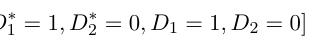

NOTE: contains mathematical notation; text above is the PDF text layer and symbols may be mis-extracted. Image shows the original.

*β*3 =E[*Y*1(1*,* 0) *−Y*1(0*,* 0) *| D<sup>∗</sup>*

**equation / math rendering (image)**

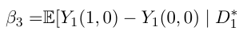

NOTE: contains mathematical notation; text above is the PDF text layer and symbols may be mis-extracted. Image shows the original.

1 <sup>= 1</sup>*<sup>, D</sup><sup>∗</sup>* 2 <sup>= 0</sup>*<sup>, D</sup>*<sup>1</sup> <sup>= 0</sup>*<sup>, D</sup>*<sup>2</sup> <sup>= 1]</sup>*<sup>P</sup>*<sup>(</sup>*<sup>D</sup><sup>∗</sup>* 1 <sup>= 1</sup>*<sup>, D</sup><sup>∗</sup>* 2 <sup>= 0</sup>*<sup>|</sup><sup>D</sup>*<sup>1</sup> <sup>= 0</sup>*<sup>, D</sup>*<sup>2</sup> <sup>= 1)+</sup>

**equation / math rendering (image)**

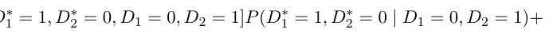

NOTE: contains mathematical notation; text above is the PDF text layer and symbols may be mis-extracted. Image shows the original.

E[*Y*1(0*,* 1) *−Y*1(0*,* 0) *| D<sup>∗</sup>*

**equation / math rendering (image)**

NOTE: contains mathematical notation; text above is the PDF text layer and symbols may be mis-extracted. Image shows the original.

1 <sup>= 0</sup>*<sup>, D</sup><sup>∗</sup>* 2 <sup>= 1</sup>*<sup>, D</sup>*<sup>1</sup> <sup>= 0</sup>*<sup>, D</sup>*<sup>2</sup> <sup>= 1]</sup>*<sup>P</sup>*<sup>(</sup>*<sup>D</sup><sup>∗</sup>* 1 <sup>= 0</sup>*<sup>, D</sup><sup>∗</sup>* 2 <sup>= 1</sup>*<sup>|</sup><sup>D</sup>*<sup>1</sup> <sup>= 0</sup>*<sup>, D</sup>*<sup>2</sup> <sup>= 1)</sup>

**equation / math rendering (image)**

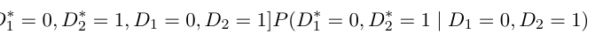

NOTE: contains mathematical notation; text above is the PDF text layer and symbols may be mis-extracted. Image shows the original.

=*ATT*1 *× P*(*D<sup>∗</sup>*

**equation / math rendering (image)**

NOTE: contains mathematical notation; text above is the PDF text layer and symbols may be mis-extracted. Image shows the original.

**equation / math rendering (image)**

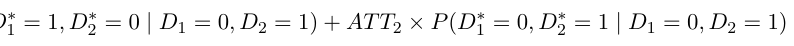

NOTE: contains mathematical notation; text above is the PDF text layer and symbols may be mis-extracted. Image shows the original.

(10)

The results stated in Proposition 10 is quite intuitive. On the one hand, since we do not have

any misclassified streamer in the observed banned group, this group of treated streamers can

be seen as a subpopulation of all streamers who indeed streamed banned content. Therefore,

the second part of Assumption 1 ensures that the treatment effect is correctly identified *in*

*the banned group*, as in any classic DiD setup. On the other hand, the observed ”unbanned”

group is a potential mixture of both “banned” and unbanned streamers, and the corresponding

DiD estimate is therefore a weighted average of the two ATTs and is attenuated towards the

direction of ATT for the “banned” group.

Since our DiD estimate for the banned group is correctly identified and is more negative

compared to the DiD estimate of the unbanned group, suggesting that the actual ATT for the

unbanned group might be nonnegative. Therefore, we adopt a sensitivity analysis based on

the above identification results to address the concerns over potential misclassification. The

sensitivity analysis is performed based on the following assumption:

#### **Assumption 2 (Bounds on Probability of Misclassification)**

1 Γ *<sup>≤</sup><sup>P</sup>*<sup>(</sup>*<sup>D</sup><sup>∗</sup>*

**equation / math rendering (image)**

NOTE: contains mathematical notation; text above is the PDF text layer and symbols may be mis-extracted. Image shows the original.

1 <sup>= 1</sup>*<sup>, D</sup><sup>∗</sup>* 2 <sup>= 0</sup>*<sup>|</sup><sup>D</sup>*<sup>1</sup> <sup>= 0</sup>*<sup>, D</sup>*<sup>2</sup> <sup>= 1)</sup> *P*(*D<sup>∗</sup>*

**equation / math rendering (image)**

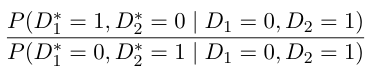

NOTE: contains mathematical notation; text above is the PDF text layer and symbols may be mis-extracted. Image shows the original.

1 <sup>= 0</sup>*<sup>, D</sup><sup>∗</sup>* 2 <sup>= 1</sup>*<sup>|</sup><sup>D</sup>*<sup>1</sup> <sup>= 0</sup>*<sup>, D</sup>*<sup>2</sup> <sup>= 1)</sup> *<sup>≤</sup>*<sup>Γ</sup>

**equation / math rendering (image)**

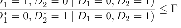

NOTE: contains mathematical notation; text above is the PDF text layer and symbols may be mis-extracted. Image shows the original.

We introduce sensitivity parameter Γ in Assumption 2, which bound the fraction between

misclassified streamers in the observed unbanned group compared to the correctly classified

streamers. It is natural to adopt this sensitivity parameter since the we can choose the value of

the sensitivity parameter based on how confident we are on the classification for each streamer

in the observed unbanned group. We derive the bounds of ATT as in the following proposition:

**equation / math rendering (image)**

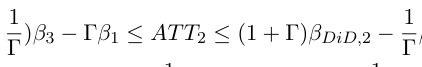

NOTE: contains mathematical notation; text above is the PDF text layer and symbols may be mis-extracted. Image shows the original.

**equation / math rendering (image)**

NOTE: contains mathematical notation; text above is the PDF text layer and symbols may be mis-extracted. Image shows the original.

(1 + Γ)*β*3 *−*<sup>1</sup>

**equation / math rendering (image)**

NOTE: contains mathematical notation; text above is the PDF text layer and symbols may be mis-extracted. Image shows the original.

Γ<sup>)</sup>*<sup>β</sup>*<sup>3</sup>*<sup>−</sup>*<sup>Γ</sup>*<sup>β</sup>*<sup>1</sup> *<sup>if</sup> <sup>β</sup><sup>d</sup> <sup><</sup>*<sup>0</sup>

**equation / math rendering (image)**

NOTE: contains mathematical notation; text above is the PDF text layer and symbols may be mis-extracted. Image shows the original.